# EDUC 152. Intro to quantitative research in education: Regression analysis

Bivariate regression

# 1 Introduction

“Bivariate regression” refers to regression models with two variables, a $Y$ variable (“dependent variable” or “outcome”) and a single $X$ variable (“independent variable”)

“Multivariate regression” refers to regression models with a $Y$ variable and two or more $X$ variables

This lecture – which we will teach over several weeks – teaches the fundamental concepts of bivariate regression. All of these concepts will be the same when we move on to multivariate regression in the subsequent lecture

## 1.1 Libraries, data, functions

**CLICK HERE FOR OZAN’S NOTES TO SELF ON WHICH YEAR OF IPEDS TUITION PRICE DATA TO MERGE TO WHICH YEAR OF SCORECARD DATA**

SCORECARD DATA

- df_debt_earn_panel_labelled, field_ay==‘2017-18’ refers to “FieldOfStudyData1617_1718”
- terms scorecard uses to refer to year/time period
  - Acad yr Academic Year; differs by institution, but generally the period from September to June (e.g., AcadYr 2013-14 = 9/1/2013 - 5/31/2014)
  - AY Award Year (e.g. AY 2013-14 = 7/1/2013-6/30/2014)
  - CY Calendar Year (e.g. CY 2014 = 1/1/14-12/31/14)
  - DCY IPEDS Data Collection Year (e.g., DCY2013-14 = the 2013-14 IPEDS collection)
- variables
  - ipedscount1 = Number of awards to all students in year 1 of the pooled debt cohort
    - for scorecard “FieldOfStudyData1617_1718” data, this refers to degrees granted in AY 2016-17 reported in IPEDS DCY2017-18
  - ipedscount2 = number of awards to all students in year 2 of the pooled debt cohort
    - for scorecard “FieldOfStudyData1617_1718” data, this refers to degrees granted in AY 2017-18 reported in IPEDS DCY2018-19
- assumptions about relationship between MA degree awards and when students started MA program
  - Most (full-time) MA programs take one or two academic years to complete
  - Assuming two years for MA degree completion:
    - students awarded MA degrees in AY 2016-17 (e.g., May 2017) initially enrolled in Fall 2015 of 2015-16 academic year (year 1 = 2015-16; year 2 = 2016-17)
      - first paid tuition in fall 2015
    - students awarded MA degrees in AY 2017-18 (e.g., May 2018) initially enrolled in Fall 2016 of 2016-17 academic year (year 1 = 2016-17; year 2 = 2017-18)
      - first paid tuition in fall 2016

IPEDS DATA

- if you are matching IPEDS tuition price to ipedscount1 of “FieldOfStudyData1617_1718” data
  - choose tuition price from fall 2015 of 2015-16 academic year
    - file ic2015 provides tuition price for 2015-16 academic year
    - in df_ipeds_panel data frame, this is associated with year==2015
- if you are matching IPEDS tuition price to ipedscount2 of “FieldOfStudyData1617_1718” data
  - choose tuition price from fall 2016 of 2016-17 academic year
    - file ic2016 provides tuition price for 2016-17 academic year
    - in df_ipeds_panel data frame, this is associated with year==2016

DECISION

- assume we are matching IPEDS tuition price to ipedscount2 of “FieldOfStudyData1617_1718” data
- therefore: filter(year==2016)

```r
# uncomment below line to remove all objects
  #rm(list = ls())

# Libraries
  #install.packages('tidyverse') # if you haven't installed already
  #install.packages('labelled') # if you haven't installed already
  #install.packages('patchwork') # if you haven't installed already

library(tidyverse) # load tidyverse package
library(labelled) # load labelled package package
library(patchwork)

##########
########## TENNESSEE STAR DATA
##########

# load star data
load(file = url('https://github.com/anyone-can-cook/educ152/raw/main/data/star/star_panel_data.RData'))

#df_star_panel %>% glimpse()

# create data frame for STAR experiment, keeping only kindergarten
df_stark <- df_star_panel %>%
  # keep only kindergarten year
  filter(grade ==1) %>%
  # keep only observations with non-missing value for reading score
  filter(!is.na(read)) %>%
  # keep only observations with non-missing values for treatment assignment
  filter(!is.na(star)) %>%
  # drop observations where treatment status is regular+aide
  filter(star !=3) %>%
  # keep selected variables
  select(id,grade,star,read,gender,ethnicity,lunch,school,degree,experience) %>%
  # create a variable "treatment" that equals 1 if student receives treatment (small class) and equals 0 otherwise
  mutate(
    treatment = if_else(star==2,1,0)
  )

df_stark %>% glimpse()
```

```
#> Rows: 3,745
#> Columns: 11
#> $ id         <dbl+lbl>   943,   986,  1915,  2020,  2130,  3053,  3219,  3455,  3821,  4273,  4377,  4564,  4779,  5022,  5091,  5570,  6013,  6071,  6095,  6137,  6194,  6211,  6232,  6320,  6331,  6341,  6364,  6371,  6402,  6449,  6506,  6545,  6560,  6582,  6602,  6671,  6722,  6793,  6800,  …
#> $ grade      <dbl+lbl> 1, 1, 1, 1, 1, 1, 1, 1, 1, 1, 1, 1, 1, 1, 1, 1, 1, 1, 1, 1, 1, 1, 1, 1, 1, 1, 1, 1, 1, 1, 1, 1, 1, 1, 1, 1, 1, 1, 1, 1, 1, 1, 1, 1, 1, 1, 1, 1, 1, 1, 1, 1, 1, 1, 1, 1, 1, 1, 1, 1, 1, 1, 1, 1, 1, 1, 1, 1, 1, 1, 1, 1, 1, 1, 1, 1, 1, 1, 1, 1, 1, 1, 1, 1, 1, 1, 1, 1, 1, 1, 1, 1…
#> $ star       <dbl+lbl> 2, 2, 1, 2, 1, 1, 2, 2, 1, 2, 2, 1, 1, 2, 1, 1, 2, 1, 1, 1, 2, 1, 2, 1, 2, 2, 2, 2, 1, 2, 2, 2, 1, 2, 2, 2, 1, 2, 1, 2, 2, 2, 1, 1, 2, 1, 2, 1, 2, 2, 1, 2, 2, 2, 1, 2, 2, 2, 1, 1, 2, 1, 1, 1, 2, 2, 2, 2, 1, 2, 2, 1, 2, 2, 1, 1, 2, 1, 1, 1, 1, 1, 2, 2, 2, 1, 2, 2, 2, 1, 2, 2…
#> $ read       <int> 447, 450, 448, 447, 431, 451, 478, 455, 430, 474, 424, 439, 437, 422, 424, 431, 456, 522, 416, 419, 418, 422, 414, 450, 458, 445, 439, 476, 467, 480, 465, 407, 487, 447, 430, 480, 440, 413, 422, 442, 410, 465, 436, 436, 428, 411, 436, 472, 443, 424, 428, 440, 433, 474, 414, 411…
#> $ gender     <dbl+lbl> 2, 2, 1, 1, 1, 2, 2, 2, 1, 1, 1, 1, 2, 2, 1, 1, 1, 2, 1, 2, 1, 2, 2, 2, 2, 2, 1, 1, 2, 1, 1, 2, 2, 2, 2, 2, 2, 2, 2, 2, 2, 2, 1, 1, 1, 1, 2, 1, 1, 1, 1, 1, 1, 1, 1, 2, 2, 2, 2, 2, 2, 2, 1, 1, 1, 2, 2, 1, 1, 2, 2, 1, 1, 2, 2, 2, 1, 2, 1, 1, 2, 1, 1, 2, 2, 2, 2, 1, 2, 1, 1, 2…
#> $ ethnicity  <dbl+lbl>  1,  2,  1,  1,  1,  1,  2,  1,  1,  1,  1,  1,  2,  1,  1,  1,  1,  1,  1,  2,  1,  2,  2,  1,  1,  1,  1,  1,  1,  1,  1,  1,  2,  1,  1,  1,  1,  1,  2,  2,  2,  2,  1,  1,  1,  2,  1,  1,  1,  1,  2,  2,  2,  2,  2,  1,  2,  1,  2,  1,  1,  1,  1,  1,  1,  1,  2,  1,  1…
#> $ lunch      <dbl+lbl>  1,  1,  1,  2,  2,  1,  1,  1,  1,  1,  1,  1,  2,  1,  2,  1,  2,  1,  1,  2,  1,  2,  2,  1,  2,  1,  1,  1,  1,  1,  1,  2,  1,  1,  1,  1,  1,  1,  2,  1,  2,  1,  1,  2,  1,  2,  1,  1,  1,  2,  2,  2,  1,  2,  2,  1,  1,  1,  2,  1,  2,  1,  1,  2,  2,  2,  2,  2,  1…
#> $ school     <dbl+lbl> 3, 2, 3, 3, 3, 3, 3, 3, 3, 2, 3, 2, 2, 3, 3, 3, 4, 4, 3, 1, 3, 3, 3, 3, 3, 4, 4, 4, 3, 2, 2, 3, 1, 2, 3, 2, 3, 3, 2, 2, 1, 1, 3, 3, 2, 1, 2, 3, 3, 3, 1, 1, 1, 2, 3, 3, 2, 3, 2, 3, 4, 3, 3, 2, 3, 2, 1, 4, 3, 2, 4, 3, 3, 3, 3, 3, 3, 3, 3, 1, 3, 1, 3, 3, 3, 2, 1, 1, 4, 2, 3, 3…
#> $ degree     <dbl+lbl> 1, 1, 1, 1, 1, 1, 1, 1, 2, 1, 1, 2, 1, 2, 1, 2, 2, 1, 2, 1, 1, 2, 1, 1, 1, 2, 2, 4, 2, 1, 2, 1, 1, 2, 2, 2, 2, 2, 1, 1, 1, 1, 1, 2, 1, 1, 2, 1, 4, 1, 1, 1, 2, 1, 2, 1, 1, 1, 1, 1, 2, 1, 2, 1, 1, 1, 1, 2, 1, 1, 2, 1, 1, 1, 2, 2, 1, 1, 1, 1, 2, 1, 1, 2, 3, 1, 1, 1, 1, 4, 2, 2…
#> $ experience <int> 7, 21, 16, 5, 8, 3, 11, 10, 13, 0, 6, 13, 1, 8, 13, 13, 14, 8, 13, 0, 8, 15, 8, 10, 4, 7, 17, 12, 4, 0, 18, 4, 12, 14, 13, 14, 5, 5, 1, 5, 2, 2, 11, 13, 5, 0, 4, 5, 8, 2, 11, 14, 13, 3, 15, 20, 11, 20, 6, 11, 12, 6, 12, 18, 2, 11, 1, 17, 0, 13, 17, 20, 4, 15, 6, 10, 4, 16, 8, 6…
#> $ treatment  <dbl> 1, 1, 0, 1, 0, 0, 1, 1, 0, 1, 1, 0, 0, 1, 0, 0, 1, 0, 0, 0, 1, 0, 1, 0, 1, 1, 1, 1, 0, 1, 1, 1, 0, 1, 1, 1, 0, 1, 0, 1, 1, 1, 0, 0, 1, 0, 1, 0, 1, 1, 0, 1, 1, 1, 0, 1, 1, 1, 0, 0, 1, 0, 0, 0, 1, 1, 1, 1, 0, 1, 1, 0, 1, 1, 0, 0, 1, 0, 0, 0, 0, 0, 1, 1, 1, 0, 1, 1, 1, 0, 1, 1, 0,…
```

```r
rm(df_star_panel) # comment this line out if you want to keep data frame df_star_panel

##########
########## IPEDS
##########

# Load ipeds dataset from course website url
load(file = url('https://github.com/anyone-can-cook/educ152/raw/main/data/ipeds/output_data/panel_data.RData'))

# Create ipeds data frame with fewer variables/observations
df_ipeds_pop <- panel_data %>%
  # keep IPEDS tuition data from fall of which year (e.g., fall 2016 is price for programs in 2016-17 academic year)
  filter(year == 2016) %>%
  # which universities to keep:
    # 2015 carnegie classification: keep research universities (15,16,17) and master's universities (18,19,20)
  filter(c15basic %in% c(15,16,17,18,19,20)) %>%
  # which variables to keep
  select(instnm,unitid,opeid6,opeid,control,c15basic,stabbr,city,zip,locale,obereg, # basic institutional characteristics
         tuition6,fee6,tuition7,fee7, # avg tuition and fees for full-time grad, in-state and out-of-state
         isprof3,ispfee3,osprof3,ospfee3, # avg tuition and fees for MD, in-state and out-of-state
         isprof9,ispfee9,osprof9,ospfee9, # avg tuition and fees for Law, in-state and out-of-state
         chg4ay3,chg7ay3,chg8ay3) %>% # [undergraduate] books+supplies; off-campus (not with family) room and board; off-campus (not with family) other expenses
  # rename variables; syntax <new_name> = <old_name>
  rename(region = obereg, # revion
         tuit_grad_res = tuition6, fee_grad_res = fee6, tuit_grad_nres = tuition7, fee_grad_nres = fee7, # grad
         tuit_md_res = isprof3, fee_md_res = ispfee3, tuit_md_nres = osprof3, fee_md_nres = ospfee3, # md
         tuit_law_res = isprof9, fee_law_res = ispfee9, tuit_law_nres = osprof9, fee_law_nres = ospfee9, # law
         books_supplies = chg4ay3, roomboard_off = chg7ay3, oth_expense_off = chg8ay3) %>% # [undergraduate] expenses
  # create measures of tuition+fees
  mutate(
    tuitfee_grad_res = tuit_grad_res + fee_grad_res, # graduate, state resident
    tuitfee_grad_nres = tuit_grad_nres + fee_grad_nres, # graduate, non-resident
    tuitfee_md_res = tuit_md_res + fee_md_res, # MD, state resident
    tuitfee_md_nres = tuit_md_nres + fee_md_nres, # MD, non-resident
    tuitfee_law_res = tuit_law_res + fee_law_res, # Law, state resident
    tuitfee_law_nres = tuit_law_nres + fee_law_nres) %>% # Law, non-resident
  # create measures of cost-of-attendance (COA) as the sum of tuition, fees, book, living expenses
  mutate(
    coa_grad_res = tuit_grad_res + fee_grad_res + books_supplies + roomboard_off + oth_expense_off, # graduate, state resident
    coa_grad_nres = tuit_grad_nres + fee_grad_nres + books_supplies + roomboard_off + oth_expense_off, # graduate, non-resident
    coa_md_res = tuit_md_res + fee_md_res + books_supplies + roomboard_off + oth_expense_off, # MD, state resident
    coa_md_nres = tuit_md_nres + fee_md_nres + books_supplies + roomboard_off + oth_expense_off, # MD, non-resident
    coa_law_res = tuit_law_res + fee_law_res + books_supplies + roomboard_off + oth_expense_off, # Law, state resident
    coa_law_nres = tuit_law_nres + fee_law_nres + books_supplies + roomboard_off + oth_expense_off) # %>% # Law, non-resident
  # [COMMENTED THIS OUT] keep only observations that have non-missing values for the variable coa_grad_res
    # this does cause us to lose some interesting universities, but doing this will eliminate some needless complications with respect to learning core concepts about statistical inference
  #filter(!is.na(coa_grad_res))

# Add variable labels to the tuit+fees variables and coa variables
  # tuition + fees variables
    var_label(df_ipeds_pop[['tuitfee_grad_res']]) <- 'graduate, full-time, resident; avg tuition + required fees'
    var_label(df_ipeds_pop[['tuitfee_grad_nres']]) <- 'graduate, full-time, non-resident; avg tuition + required fees'
    var_label(df_ipeds_pop[['tuitfee_md_res']]) <- 'MD, full-time, state resident; avg tuition + required fees'
    var_label(df_ipeds_pop[['tuitfee_md_nres']]) <- 'MD, full-time, non-resident; avg tuition + required fees'
    var_label(df_ipeds_pop[['tuitfee_law_res']]) <- 'Law, full-time, state resident; avg tuition + required fees'
    var_label(df_ipeds_pop[['tuitfee_law_nres']]) <- 'Law, full-time, non-resident; avg tuition + required fees'

  # COA variables
    var_label(df_ipeds_pop[['coa_grad_res']]) <- 'graduate, full-time, state resident COA; == tuition + fees + (ug) books/supplies + (ug) off-campus room and board + (ug) off-campus other expenses'
    var_label(df_ipeds_pop[['coa_grad_nres']]) <- 'graduate, full-time, non-resident COA; == tuition + fees + (ug) books/supplies + (ug) off-campus room and board + (ug) off-campus other expenses'
    var_label(df_ipeds_pop[['coa_md_res']]) <- 'MD, full-time, state resident COA; == tuition + fees + (ug) books/supplies + (ug) off-campus room and board + (ug) off-campus other expenses'
    var_label(df_ipeds_pop[['coa_md_nres']]) <- 'MD, full-time, non-resident COA; == tuition + fees + (ug) books/supplies + (ug) off-campus room and board + (ug) off-campus other expenses'
    var_label(df_ipeds_pop[['coa_law_res']]) <- 'Law, full-time, state resident COA; == tuition + fees + (ug) books/supplies + (ug) off-campus room and board + (ug) off-campus other expenses'
    var_label(df_ipeds_pop[['coa_law_nres']]) <- 'Law, full-time, non-resident COA; == tuition + fees + (ug) books/supplies + (ug) off-campus room and board + (ug) off-campus other expenses'

  #df_ipeds_pop %>% glimpse()

rm(panel_data) # comment this line out if you want to keep data frame panel_data

##########
########## SCORECARD DATA ON DEBT AND EARNINGS
##########

# load scorecard dataset from course website url

load(file = url('https://github.com/anyone-can-cook/educ152/raw/main/data/college_scorecard/output_data/df_debt_earn_panel_labelled.RData'))

df_scorecard <- df_debt_earn_panel_labelled %>%
    # keep most recent year of data
    filter(field_ay == '2017-18') %>%
    # keep master's degrees
    filter(credlev == 5) %>%
    # carnegie categories to keep: 15 = Doctoral Universities: Very High Research Activity; 16 = Doctoral Universities: High Research Activity
      # note: variable ccbasic from scorecard data is 2015 carnegie classification
    filter(ccbasic %in% c(15,16,17,18,19,20)) %>%
    # drop "parent plus" loan variables and other vars we won't use in this lecture
    select(-contains('_pp'),-contains('_any'),-field_ay,-st_fips,-zip,-longitude,-latitude,-locale2,-highdeg,-accredagency,-relaffil,-hbcu,-annhi,-tribal,-aanapii,-hsi,-nanti,-main,-numbranch,-control) %>%
    # create variable for broad field of degree (e.g., education, business)
    mutate(cipdig2 = str_sub(string = cipcode, start = 1, end = 2)) %>%
    # shorten variable cipdesc to make it more suitable for printing
    mutate(cipdesc = str_sub(string = cipdesc, start = 1, end = 50)) %>%
    # re-order variables
    relocate(opeid6,unitid,instnm,ccbasic,stabbr,city,cipdig2)

  #df_scorecard %>% glimpse()

# For debt and earnings variables, convert from character to numeric variables (which replaces "PrivacySuppressed" values with NA values)
df_scorecard <- df_scorecard %>%
  mutate(
    debt_all_stgp_eval_n = as.numeric(debt_all_stgp_eval_n),
    debt_all_stgp_eval_mean = as.numeric(debt_all_stgp_eval_mean),
    debt_all_stgp_eval_mdn = as.numeric(debt_all_stgp_eval_mdn),
    debt_all_stgp_eval_mdn10yrpay = as.numeric(debt_all_stgp_eval_mdn10yrpay),
    earn_count_wne_hi_1yr = as.numeric(earn_count_wne_hi_1yr),
    earn_mdn_hi_1yr = as.numeric(earn_mdn_hi_1yr),
    earn_count_wne_hi_2yr = as.numeric(earn_count_wne_hi_2yr),
    earn_mdn_hi_2yr = as.numeric(earn_mdn_hi_2yr)
  )

# add variable label to variable cipdig2
  attr(df_scorecard[['cipdig2']], which = 'label') <- 'broad degree field code = 2-digit classification of instructional programs (CIP) degree code'

# add variable label attribute back to debt and earnings variables
  for(v in c('debt_all_stgp_eval_n','debt_all_stgp_eval_mean','debt_all_stgp_eval_mdn','debt_all_stgp_eval_mdn10yrpay','earn_count_wne_hi_1yr','earn_mdn_hi_1yr','earn_count_wne_hi_2yr','earn_mdn_hi_2yr','cipdesc')) {

    #writeLines(str_c('object v=', v))
    #writeLines(attr(df_debt_earn_panel_labelled[[v]], which = 'label'))

    attr(df_scorecard[[v]], which = 'label') <- attr(df_debt_earn_panel_labelled[[v]], which = 'label')
  }

#df_scorecard %>% glimpse()

rm(df_debt_earn_panel_labelled) # comment this line out if you want to keep data frame df_debt_earn_panel_labelled
#earn_mdn_hi_2yr

##########
########## LEFT JOIN SCORECARD AND IPEDS DATA
##########

# investigate data structure

  # df_scorecard; these vars uniquely identify observations
    df_scorecard %>% group_by(opeid6,cipcode) %>% summarise(n_per_key=n()) %>% ungroup() %>% count(n_per_key)
```

```
#> # A tibble: 1 x 2
#>   n_per_key     n
#>       <int> <int>
#> 1         1 28057
```

```r
  # df_ipeds_pop: these vars uniquely identify observations
    df_ipeds_pop %>% group_by(unitid) %>% summarise(n_per_key=n()) %>% ungroup() %>% count(n_per_key)
```

```
#> # A tibble: 1 x 2
#>   n_per_key     n
#>       <int> <int>
#> 1         1  1091
```

```r
# join
  # start with df_ipeds_pop, keep selected variables; then do do a right_join (i.e., keep obs in y table)

  df_score_ipeds <- df_ipeds_pop %>%
    select(-instnm,-opeid6,-opeid,-c15basic,-region,-locale,-city,-stabbr,-zip) %>% mutate(one=1) %>%
    right_join(y=df_scorecard, by = 'unitid')
     #df_score_ipeds %>% glimpse()

  # 52 unitids from scorecard that don't have a match in ipeds
    # could be due to differences in year; decision: drop thiese
    df_score_ipeds %>% filter(is.na(one)) %>% count(unitid) # 52 unitids from scorecard data with missing IPEDS data
```

```
#> # A tibble: 52 x 2
#>    unitid     n
#>     <dbl> <int>
#>  1 108232    21
#>  2 127556     5
#>  3 140872     7
#>  4 140988     3
#>  5 150941     6
#>  6 151290     4
#>  7 152381     3
#>  8 152567     6
#>  9 153001     8
#> 10 153126     3
#> # ... with 42 more rows
```

```r
    df_score_ipeds %>% filter(is.na(one)) %>% count(instnm) # 52 unitids from scorecard data with missing IPEDS data
```

```
#> # A tibble: 52 x 2
#>    instnm                        n
#>    <chr>                     <int>
#>  1 Academy of Art University    21
#>  2 Augustana University          4
#>  3 Baker College                12
#>  4 Buena Vista University        8
#>  5 Calvin University             7
#>  6 Cedar Crest College           9
#>  7 Cedarville University         4
#>  8 Clarke University             3
#>  9 Coker University              3
#> 10 Colorado Mesa University      5
#> # ... with 42 more rows
```

```r
  df_score_ipeds <- df_score_ipeds %>%
    # drop unitids from scorecard that don't merge to ipeds data (on tuition)
    filter(!is.na(one)) %>%
    # drop observations that don't have mean debt data
    filter(!is.na(debt_all_stgp_eval_mean)) %>%
    # drop for-profits
    filter(control !=3) %>%
    # drop tuition/coa vars for law and md
    select(-one,-contains('law'),-contains('md_')) %>%
    relocate(opeid6,unitid,instnm,control,ccbasic,stabbr,region,city,locale,cipdig2,cipcode,cipdesc,credlev,creddesc,
      contains('ipeds'),starts_with('debt'),starts_with('earn'))

  df_score_ipeds %>% glimpse()
```

```
#> Rows: 9,444
#> Columns: 35
#> $ opeid6                        <chr> "001002", "001002", "001002", "001002", "001002", "001002", "001002", "001002", "001002", "001002", "001002", "001002", "001052", "001052", "001052", "001052", "001052", "001052", "001052", "001052", "001052", "001052", "001052", "001052", "001052", "001052",…
#> $ unitid                        <dbl> 100654, 100654, 100654, 100654, 100654, 100654, 100654, 100654, 100654, 100654, 100654, 100654, 100663, 100663, 100663, 100663, 100663, 100663, 100663, 100663, 100663, 100663, 100663, 100663, 100663, 100663, 100663, 100663, 100663, 100663, 100663, 100663, 100…
#> $ instnm                        <chr> "Alabama A & M University", "Alabama A & M University", "Alabama A & M University", "Alabama A & M University", "Alabama A & M University", "Alabama A & M University", "Alabama A & M University", "Alabama A & M University", "Alabama A & M University", "Alabam…
#> $ control                       <dbl+lbl> 1, 1, 1, 1, 1, 1, 1, 1, 1, 1, 1, 1, 1, 1, 1, 1, 1, 1, 1, 1, 1, 1, 1, 1, 1, 1, 1, 1, 1, 1, 1, 1, 1, 1, 1, 1, 2, 2, 1, 1, 1, 1, 1, 1, 1, 1, 1, 1, 1, 1, 1, 1, 1, 1, 1, 1, 1, 1, 1, 1, 1, 1, 1, 1, 1, 1, 1, 1, 1, 1, 1, 1, 1, 1, 1, 1, 1, 1, 1, 1, 1, 1, 1, 1, 1, …
#> $ ccbasic                       <dbl+lbl> 18, 18, 18, 18, 18, 18, 18, 18, 18, 18, 18, 18, 15, 15, 15, 15, 15, 15, 15, 15, 15, 15, 15, 15, 15, 15, 15, 15, 15, 15, 15, 15, 15, 15, 15, 15, 20, 20, 16, 16, 16, 16, 19, 19, 19, 19, 19, 15, 15, 15, 15, 15, 15, 15, 15, 15, 15, 15, 15, 15, 15, 15, 15, 15,…
#> $ stabbr                        <chr> "AL", "AL", "AL", "AL", "AL", "AL", "AL", "AL", "AL", "AL", "AL", "AL", "AL", "AL", "AL", "AL", "AL", "AL", "AL", "AL", "AL", "AL", "AL", "AL", "AL", "AL", "AL", "AL", "AL", "AL", "AL", "AL", "AL", "AL", "AL", "AL", "AL", "AL", "AL", "AL", "AL", "AL", "AL", "…
#> $ region                        <dbl+lbl> 5, 5, 5, 5, 5, 5, 5, 5, 5, 5, 5, 5, 5, 5, 5, 5, 5, 5, 5, 5, 5, 5, 5, 5, 5, 5, 5, 5, 5, 5, 5, 5, 5, 5, 5, 5, 5, 5, 5, 5, 5, 5, 5, 5, 5, 5, 5, 5, 5, 5, 5, 5, 5, 5, 5, 5, 5, 5, 5, 5, 5, 5, 5, 5, 5, 5, 5, 5, 5, 5, 5, 5, 5, 5, 5, 5, 5, 5, 5, 5, 5, 5, 5, 5, 5, …
#> $ city                          <chr> "Normal", "Normal", "Normal", "Normal", "Normal", "Normal", "Normal", "Normal", "Normal", "Normal", "Normal", "Normal", "Birmingham", "Birmingham", "Birmingham", "Birmingham", "Birmingham", "Birmingham", "Birmingham", "Birmingham", "Birmingham", "Birmingham",…
#> $ locale                        <dbl+lbl> 12, 12, 12, 12, 12, 12, 12, 12, 12, 12, 12, 12, 12, 12, 12, 12, 12, 12, 12, 12, 12, 12, 12, 12, 12, 12, 12, 12, 12, 12, 12, 12, 12, 12, 12, 12, 12, 12, 12, 12, 12, 12, 12, 12, 12, 12, 12, 12, 12, 12, 12, 12, 12, 12, 12, 12, 12, 12, 12, 12, 12, 12, 12, 12,…
#> $ cipdig2                       <chr> "09", "11", "13", "13", "14", "19", "26", "31", "42", "44", "51", "52", "09", "13", "13", "13", "13", "13", "13", "14", "23", "26", "26", "30", "44", "45", "51", "51", "51", "51", "51", "51", "51", "52", "52", "52", "19", "52", "13", "51", "52", "52", "13", "…
#> $ cipcode                       <chr> "0901", "1101", "1304", "1312", "1499", "1901", "2601", "3105", "4228", "4407", "5102", "5202", "0901", "1304", "1310", "1311", "1312", "1313", "1314", "1401", "2301", "2601", "2612", "3019", "4404", "4511", "5107", "5109", "5110", "5122", "5123", "5131", "51…
#> $ cipdesc                       <chr> "Communication and Media Studies.", "Computer and Information Sciences, General.", "Educational Administration and Supervision.", "Teacher Education and Professional Development, Sp", "Engineering, Other.", "Family and Consumer Sciences/Human Sciences, Gener"…
#> $ credlev                       <dbl+lbl> 5, 5, 5, 5, 5, 5, 5, 5, 5, 5, 5, 5, 5, 5, 5, 5, 5, 5, 5, 5, 5, 5, 5, 5, 5, 5, 5, 5, 5, 5, 5, 5, 5, 5, 5, 5, 5, 5, 5, 5, 5, 5, 5, 5, 5, 5, 5, 5, 5, 5, 5, 5, 5, 5, 5, 5, 5, 5, 5, 5, 5, 5, 5, 5, 5, 5, 5, 5, 5, 5, 5, 5, 5, 5, 5, 5, 5, 5, 5, 5, 5, 5, 5, 5, 5, …
```

[output cut: 22 more lines]

```r
rm(df_ipeds_pop) # comment this line out if you want to keep ipeds data frame
rm(df_scorecard) # comment this line out if you want to keep scorecard data frame

# Investigate analysis data frame `df_score_ipeds`

  # data structure: variables that uniquely identify obs
    df_score_ipeds %>% group_by(opeid6,cipcode) %>% summarise(n_per_key=n()) %>% ungroup() %>% count(n_per_key)
```

```
#> # A tibble: 1 x 2
#>   n_per_key     n
#>       <int> <int>
#> 1         1  9444
```

```r
  # number of observations (universities) for each 4-digit cip code (degree code)
    #df_score_ipeds %>% count(cipcode)
    df_score_ipeds %>% filter(cipcode=='4407') %>% count(cipcode) # social work
```

```
#> # A tibble: 1 x 2
#>   cipcode     n
#>   <chr>   <int>
#> 1 4407      257
```

```r
# create data frame that only contains observations for MAs in social work; filter(cipcode=='4407')
  df_socialwork <- df_score_ipeds %>%
    filter(cipcode=='4407') %>%
    # remove observations with missing values of cost of attendance (better for teaching concepts)
    filter(!is.na(coa_grad_res))

  df_socialwork %>% glimpse()
```

```
#> Rows: 253
#> Columns: 35
#> $ opeid6                        <chr> "001002", "001005", "001051", "001036", "001047", "011462", "001081", "001101", "001108", "001090", "001117", "007993", "001157", "001142", "001146", "001141", "001147", "001137", "001138", "001139", "001140", "001153", "001150", "001315", "001149", "001151",…
#> $ unitid                        <dbl> 100654, 100724, 100751, 102049, 102368, 102553, 104151, 106245, 106397, 106458, 109785, 110486, 110495, 110510, 110538, 110547, 110556, 110565, 110574, 110583, 110592, 110608, 110617, 110662, 115755, 122409, 122597, 122755, 123961, 126818, 127060, 127565, 129…
#> $ instnm                        <chr> "Alabama A & M University", "Alabama State University", "The University of Alabama", "Samford University", "Troy University", "University of Alaska Anchorage", "Arizona State University-Tempe", "University of Arkansas at Little Rock", "University of Arkansas"…
#> $ control                       <dbl+lbl> 1, 1, 1, 2, 1, 1, 1, 1, 1, 1, 2, 1, 1, 1, 1, 1, 1, 1, 1, 1, 1, 1, 1, 1, 1, 1, 1, 1, 2, 1, 2, 1, 1, 2, 2, 1, 1, 2, 2, 1, 1, 1, 1, 2, 2, 1, 1, 1, 1, 1, 1, 1, 1, 2, 1, 2, 2, 1, 2, 1, 1, 1, 2, 1, 2, 2, 1, 1, 1, 1, 1, 1, 1, 1, 2, 1, 2, 1, 1, 2, 2, 1, 1, 1, 2, …
#> $ ccbasic                       <dbl+lbl> 18, 19, 15, 17, 18, 18, 15, 16, 15, 16, 16, 18, 18, 18, 18, 18, 17, 18, 18, 18, 18, 18, 18, 15, 19, 16, 18, 18, 15, 15, 16, 18, 15, 17, 17, 18, 16, 16, 17, 15, 16, 15, 15, 16, 18, 15, 18, 19, 15, 15, 20, 17, 15, 18, 16, 18, 17, 18, 16, 18, 15, 16, 16, 18,…
#> $ stabbr                        <chr> "AL", "AL", "AL", "AL", "AL", "AK", "AZ", "AR", "AR", "AR", "CA", "CA", "CA", "CA", "CA", "CA", "CA", "CA", "CA", "CA", "CA", "CA", "CA", "CA", "CA", "CA", "CA", "CA", "CA", "CO", "CO", "CO", "CT", "CT", "CT", "CT", "DE", "DC", "FL", "FL", "FL", "FL", "FL", "…
#> $ region                        <dbl+lbl> 5, 5, 5, 5, 5, 8, 6, 5, 5, 5, 8, 8, 8, 8, 8, 8, 8, 8, 8, 8, 8, 8, 8, 8, 8, 8, 8, 8, 8, 7, 7, 7, 1, 1, 1, 1, 2, 2, 5, 5, 5, 5, 5, 5, 5, 5, 5, 5, 5, 5, 5, 5, 8, 8, 7, 7, 3, 3, 3, 3, 3, 3, 3, 3, 3, 3, 3, 3, 3, 3, 3, 3, 4, 4, 4, 4, 4, 4, 4, 5, 5, 5, 5, 5, 5, …
#> $ city                          <chr> "Normal", "Montgomery", "Tuscaloosa", "Birmingham", "Troy", "Anchorage", "Tempe", "Little Rock", "Fayetteville", "Jonesboro", "Azusa", "Bakersfield", "Turlock", "San Bernardino", "Chico", "Carson", "Fresno", "Fullerton", "Hayward", "Long Beach", "Los Angeles"…
#> $ locale                        <dbl+lbl> 12, 12, 12, 21, 33, 11, 12, 12, 13, 13, 21, 11, 23, 12, 13, 13, 11, 21, 21, 11, 11, 11, 11, 11, 33, 11, 11, 11, 11, 12, 11, 11, 21, 21, 21, 12, 13, 11, 21, 21, 12, 21, 12, 21, 23, 11, 13, 13, 11, 12, 12, 13, 11, 11, 12, 22, 21, 11, 11, 41, 11, 22, 11, 11,…
#> $ cipdig2                       <chr> "44", "44", "44", "44", "44", "44", "44", "44", "44", "44", "44", "44", "44", "44", "44", "44", "44", "44", "44", "44", "44", "44", "44", "44", "44", "44", "44", "44", "44", "44", "44", "44", "44", "44", "44", "44", "44", "44", "44", "44", "44", "44", "44", "…
#> $ cipcode                       <chr> "4407", "4407", "4407", "4407", "4407", "4407", "4407", "4407", "4407", "4407", "4407", "4407", "4407", "4407", "4407", "4407", "4407", "4407", "4407", "4407", "4407", "4407", "4407", "4407", "4407", "4407", "4407", "4407", "4407", "4407", "4407", "4407", "44…
#> $ cipdesc                       <chr> "Social Work.", "Social Work.", "Social Work.", "Social Work.", "Social Work.", "Social Work.", "Social Work.", "Social Work.", "Social Work.", "Social Work.", "Social Work.", "Social Work.", "Social Work.", "Social Work.", "Social Work.", "Social Work.", "So…
#> $ credlev                       <dbl+lbl> 5, 5, 5, 5, 5, 5, 5, 5, 5, 5, 5, 5, 5, 5, 5, 5, 5, 5, 5, 5, 5, 5, 5, 5, 5, 5, 5, 5, 5, 5, 5, 5, 5, 5, 5, 5, 5, 5, 5, 5, 5, 5, 5, 5, 5, 5, 5, 5, 5, 5, 5, 5, 5, 5, 5, 5, 5, 5, 5, 5, 5, 5, 5, 5, 5, 5, 5, 5, 5, 5, 5, 5, 5, 5, 5, 5, 5, 5, 5, 5, 5, 5, 5, 5, 5, …
```

[output cut: 22 more lines]

```r
  # investigate data structure
    # one observation per opeid6
    df_socialwork %>% group_by(opeid6) %>% summarise(n_per_key=n()) %>% ungroup() %>% count(n_per_key)
```

```
#> # A tibble: 1 x 2
#>   n_per_key     n
#>       <int> <int>
#> 1         1   253
```

```r
    # also, one observation per unitid
    df_socialwork %>% group_by(unitid) %>% summarise(n_per_key=n()) %>% ungroup() %>% count(n_per_key)
```

```
#> # A tibble: 1 x 2
#>   n_per_key     n
#>       <int> <int>
#> 1         1   253
```

```r
##########
########## RUN SCRIPT THAT CREATES USER DEFINED FUNCTIONS
##########

source(file = url('https://github.com/anyone-can-cook/educ152/raw/main/scripts/user_defined_functions/create_inference_functions.R'))
```

## 1.2 Example research question

### 1.2.1 Cost of attendance (X) and student debt (Y), MA in social work

**Data**

- We will use the data frame `df_socialwork`, which includes debt/earnings data from College Scorecard and tuition/cost of attendance data from IPEDS
- each observation $i$ represents a postsecondary institution, so this is “institution level” data (or you could say university level data)
- sample includes public and private non-profit universities that:
  - 1. offer an MA in social work
  - 2. we know institution-level (average) student debt accrued from MA programs in social work
- Population our sample is meant to represent
  - Our population of interest is all public and private non-profit universities that offer an MA in social work
  - Pretend our sample is a random sample from this population
  - (In reality, our sample is not a random sample because our sample consists of universities with social work MA programs with large enough enrollment that College Scorecard did not suppress student debt data because of privacy concerns)

**Variables of interest**

- $X$ (independent variable) = `coa_grad_res` = annual full-time graduate resident cost of attendance (tuition+fees+books+living expenses)
  - *note.* at private institutions, tuition price does not differ for state residents vs. nonresidents
- $Y$ (dependent variable) = `debt_all_stgp_eval_mean` = institution-level student debt from federal Direct Loans and Grad Plus loans
  - This is the average (mean) student debt from students who completed an MA program in social work at that institution
  - *note.* In the lecture, I call this variable “institution-level student debt” rather than “average student debt” or “mean student debt” because the latter two names will be confusing when we calculate the mean of this variable and when apply concepts like sampling distribution to this variable

**Research question (RQ) of interest**

- What is the effect of (annual) cost of attendance for MA in social work programs ($X$) on institution-level student debt ($Y$) for graduates of MA programs in social work?
  - think of it as, what is the causal effect of an increase in cost of attendance on the amount of student debt typically accrued by students who graduate from MA in social work programs
  - We are answering this question using institution-level data, but if we had access to student-level data, we would answer this question using student-level data

Some descriptive statistics about our variables of interest and other interesting variables

- show variable labels for variables
- show mean values

```r
# show labels for variables
  df_socialwork %>% select(tuitfee_grad_res,tuit_grad_nres,coa_grad_res,coa_grad_nres,debt_all_stgp_eval_mean,debt_all_stgp_eval_mdn,debt_all_stgp_eval_mdn10yrpay,earn_mdn_hi_2yr) %>% var_label()
```

```
#> $tuitfee_grad_res
#> [1] "graduate, full-time, resident; avg tuition + required fees"
#>
#> $tuit_grad_nres
#> [1] "Out-of-state average tuition full-time graduates"
#>
#> $coa_grad_res
#> [1] "graduate, full-time, state resident COA; == tuition + fees + (ug) books/supplies + (ug) off-campus room and board + (ug) off-campus other expenses"
#>
#> $coa_grad_nres
#> [1] "graduate, full-time, non-resident COA; == tuition + fees + (ug) books/supplies + (ug) off-campus room and board + (ug) off-campus other expenses"
#>
#> $debt_all_stgp_eval_mean
#> [1] "Average Stafford and Grad PLUS loan debt disbursed at this institution"
#>
#> $debt_all_stgp_eval_mdn
#> [1] "Median Stafford and Grad PLUS loan debt disbursed at this institution"
#>
#> $debt_all_stgp_eval_mdn10yrpay
#> [1] "Median estimated monthly payment for Stafford and Grad PLUS loan debt disbursed at this institution"
#>
#> $earn_mdn_hi_2yr
#> [1] "Median earnings of graduates working and not enrolled 2 years after completing highest credential"
```

```r
# mean values for interesting variables
  df_socialwork %>%
    summarize(
      n = n(),
      tuitfee_grad_res = mean(tuitfee_grad_res, na.rm = TRUE),
      tuitfee_grad_nres = mean(tuitfee_grad_nres, na.rm = TRUE),
      coa_grad_res = mean(coa_grad_res, na.rm = TRUE),
      coa_grad_nres = mean(coa_grad_nres, na.rm = TRUE),
      debt = mean(debt_all_stgp_eval_mean, na.rm = TRUE),  # institution-level mean debt
      debt_mdn = mean(debt_all_stgp_eval_mdn, na.rm = TRUE), # institution-level median debt
      debt_per_mth = mean(debt_all_stgp_eval_mdn10yrpay, na.rm = TRUE),
      earn_2yr = mean(earn_mdn_hi_2yr, na.rm = TRUE),
    )
```

```
#> # A tibble: 1 x 9
#>       n tuitfee_grad_res tuitfee_grad_nres coa_grad_res coa_grad_nres   debt debt_mdn debt_per_mth earn_2yr
#>   <int>            <dbl>             <dbl>        <dbl>         <dbl>  <dbl>    <dbl>        <dbl>    <dbl>
#> 1   253           13117.            20728.       28532.        36143. 41084.   39409.         405.   45406.
```

```r
# mean values separately by public vs. private
  df_socialwork %>% group_by(control) %>%
    summarize(
      n = n(),
      tuitfee_grad_res = mean(tuitfee_grad_res, na.rm = TRUE),
      tuitfee_grad_nres = mean(tuitfee_grad_nres, na.rm = TRUE),
      coa_grad_res = mean(coa_grad_res, na.rm = TRUE),
      coa_grad_nres = mean(coa_grad_nres, na.rm = TRUE),
      debt = mean(debt_all_stgp_eval_mean, na.rm = TRUE),  # institution-level mean debt
      debt_mdn = mean(debt_all_stgp_eval_mdn, na.rm = TRUE), # institution-level median debt
      debt_per_mth = mean(debt_all_stgp_eval_mdn10yrpay, na.rm = TRUE),
      earn_2yr = mean(earn_mdn_hi_2yr, na.rm = TRUE),
    )
```

```
#> # A tibble: 2 x 10
#>                      control     n tuitfee_grad_res tuitfee_grad_nres coa_grad_res coa_grad_nres   debt debt_mdn debt_per_mth earn_2yr
#>                    <dbl+lbl> <int>            <dbl>             <dbl>        <dbl>         <dbl>  <dbl>    <dbl>        <dbl>    <dbl>
#> 1 1 [Public]                   186            9887.            20240.       25109.        35461. 37018.   35365.         363.   45679.
#> 2 2 [Private not-for-profit]    67           22083.            22083.       38034.        38034. 52372.   50658.         520.   44599.
```

- show sample sizes

```r
# sample sizes for interesting variables
  df_socialwork %>%
    summarize(
      n = n(),
      tuitfee_grad_res_n = sum(!is.na(tuitfee_grad_res)),
      tuitfee_grad_nres_n = sum(!is.na(tuitfee_grad_nres)),
      coa_grad_res_n = sum(!is.na(coa_grad_res)),
      coa_grad_nres_n = sum(!is.na(coa_grad_nres)),
      debt_n = sum(!is.na(debt_all_stgp_eval_mean)),  # institution-level mean debt
      debt_mdn_n = sum(!is.na(debt_all_stgp_eval_mean)), # institution-level median debt
      debt_mth_n = sum(!is.na(debt_all_stgp_eval_mdn10yrpay)),
      earn_2yr_n = sum(!is.na(earn_mdn_hi_2yr)),
    )
```

```
#> # A tibble: 1 x 9
#>       n tuitfee_grad_res_n tuitfee_grad_nres_n coa_grad_res_n coa_grad_nres_n debt_n debt_mdn_n debt_mth_n earn_2yr_n
#>   <int>              <int>               <int>          <int>           <int>  <int>      <int>      <int>      <int>
#> 1   253                253                 253            253             253    253        253        242        233
```

```r
  # separately bt public vs. private
  df_socialwork %>% group_by(control) %>%
    summarize(
      n = n(),
      tuitfee_grad_res_n = sum(!is.na(tuitfee_grad_res)),
      tuitfee_grad_nres_n = sum(!is.na(tuitfee_grad_nres)),
      coa_grad_res_n = sum(!is.na(coa_grad_res)),
      coa_grad_nres_n = sum(!is.na(coa_grad_nres)),
      debt_n = sum(!is.na(debt_all_stgp_eval_mean)),  # institution-level mean debt
      debt_mdn_n = sum(!is.na(debt_all_stgp_eval_mean)), # institution-level median debt
      debt_mth_n = sum(!is.na(debt_all_stgp_eval_mdn10yrpay)),
      earn_2yr_n = sum(!is.na(earn_mdn_hi_2yr)),
    )
```

```
#> # A tibble: 2 x 10
#>                      control     n tuitfee_grad_res_n tuitfee_grad_nres_n coa_grad_res_n coa_grad_nres_n debt_n debt_mdn_n debt_mth_n earn_2yr_n
#>                    <dbl+lbl> <int>              <int>               <int>          <int>           <int>  <int>      <int>      <int>      <int>
#> 1 1 [Public]                   186                186                 186            186             186    186        186        178        174
#> 2 2 [Private not-for-profit]    67                 67                  67             67              67     67         67         64         59
```

List of individual observations (each observation is a university)

```r
#df_socialwork %>% glimpse()
df_socialwork %>% select(instnm,control,coa_grad_res,debt_all_stgp_eval_mean,debt_all_stgp_eval_mdn10yrpay,earn_mdn_hi_2yr) %>% var_label()
```

```
#> $instnm
#> [1] "Institution name"
#>
#> $control
#> [1] "Control of institution"
#>
#> $coa_grad_res
#> [1] "graduate, full-time, state resident COA; == tuition + fees + (ug) books/supplies + (ug) off-campus room and board + (ug) off-campus other expenses"
#>
#> $debt_all_stgp_eval_mean
#> [1] "Average Stafford and Grad PLUS loan debt disbursed at this institution"
#>
#> $debt_all_stgp_eval_mdn10yrpay
#> [1] "Median estimated monthly payment for Stafford and Grad PLUS loan debt disbursed at this institution"
#>
#> $earn_mdn_hi_2yr
#> [1] "Median earnings of graduates working and not enrolled 2 years after completing highest credential"
```

```r
df_socialwork %>% select(instnm,control,coa_grad_res,debt_all_stgp_eval_mean,debt_all_stgp_eval_mdn10yrpay,earn_mdn_hi_2yr)
```

```
#> # A tibble: 253 x 6
#>    instnm                                                   control coa_grad_res debt_all_stgp_eval_mean debt_all_stgp_eval_mdn10yrpay earn_mdn_hi_2yr
#>    <chr>                                                  <dbl+lbl>        <dbl>                   <dbl>                         <dbl>           <dbl>
#>  1 Alabama A & M University              1 [Public]                        22886                   51788                           518           37819
#>  2 Alabama State University              1 [Public]                        21606                   38001                           421              NA
#>  3 The University of Alabama             1 [Public]                        28836                   32830                           316           38981
#>  4 Samford University                    2 [Private not-for-profit]        35488                   49278                            NA              NA
#>  5 Troy University                       1 [Public]                        20119                   30072                           238           38289
#>  6 University of Alaska Anchorage        1 [Public]                        32096                   30364                           275           51750
#>  7 Arizona State University-Tempe        1 [Public]                        26533                   45258                           421           46118
#>  8 University of Arkansas at Little Rock 1 [Public]                        25618                   41114                           443           47877
#>  9 University of Arkansas                1 [Public]                        23832                   27713                           277           44595
#> 10 Arkansas State University-Main Campus 1 [Public]                        21167                   30749                           278           45383
#> # ... with 243 more rows
```

# 2 Review: scatterplot, covariance, correlation

**Relationships between two continuous variables**

Postive relationship, negative relationship, and no relationships

Relationship between X and Y is positive

- when X is “high”, Y tend to be “high”
- when X is “low”, Y tends to be “low”
- e.g., number of hours (X) studying and GPA (Y)
- e.g., cost of attendance (X) and student debt (Y)

Relationship between X and Y is negative

- when X is “high”, Y tend to be “low”
- when X is “low”, Y tends to be “high”
- e.g., number of school absences and GPA

No relationship between X and Y

- knowing the value of X gives you does not tell you much about the value of Y
- e.g., amount of ice cream consumed and GPA

we will use the data frame `df_socialwork` (which combines debt/earnings data from College Scorecard and tuition/cost of attendance data from IPEDS) to run regression models of the relationship between measures of tuition/COA (X variable) and debt/earnings (Y variable) for MA programs in social work

Ways to investigate this relationship between X and Y:

- Graphically: scatterplots
- Numerically: covariance (less used), correlation

## 2.1 Scatterplots

Scatterplots will plot individual observations on an X and Y axis

Draw scatterplot of X (`coa_grad_res`) and Y (`debt_all_stgp_eval_mean`)

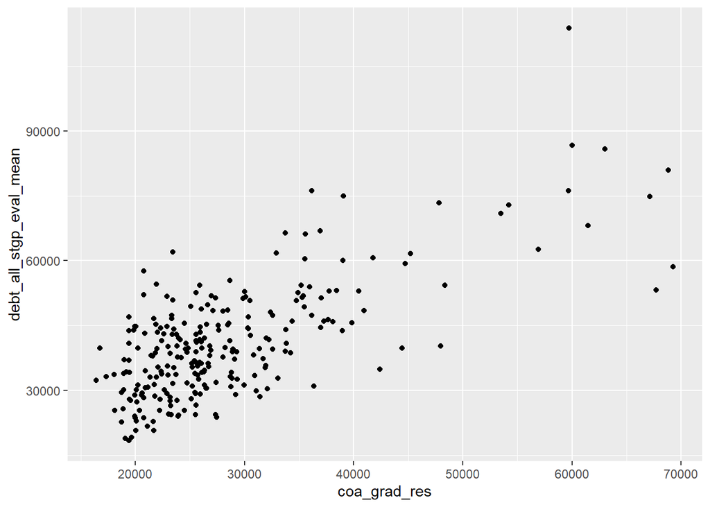

```r
df_socialwork %>%  ggplot(aes(x=coa_grad_res, y=debt_all_stgp_eval_mean)) + geom_point()
```

Create scatterplot with “prediction” line

```r
df_socialwork %>%  ggplot(aes(x=coa_grad_res, y=debt_all_stgp_eval_mean)) + geom_point() + stat_smooth(method = 'lm')
```

[output not shown]

- Residual
  - Difference between actual observed value of Y and predicted value of Y (given X)
  - predicted value of Y for a given value of X is represented by the “prediction line” above

## 2.2 Covariance

Covariance measures the extent to which two variables move together….

- If debt is “high” when cost of attendance is “high”, then covariance is positive
  - (“high” means a value that is higher than the mean value for the variable)
- If debt is “low” when cost of attendance is “high”, then covariance is negative
  - (low" means a value that is lower than the mean value for the variable)

Population covariance, denoted $cov(X, Y)$ or $\sigma_{XY}$

- As with all population parameters, we don’t know this!

Sample covariance, $s_{XY}$ or $\hat{\sigma}_{XY}$

- Estimator of population covariance
- $s_{XY}= \hat{\sigma}_{XY}=\frac{\sum_{i=1}^{n}\left(X_{i}-\bar{X} \right) \left( Y_{i}-\bar{Y} \right)}{n-1}$

Example: Imagine we have 20 obs; $\bar{X}=40; \bar{Y}=30$

Observation 1: $X_1=50; Y_1=60$

- $(X_{i}-\bar{X})( Y_{i}-\bar{Y})=(50-40)(60-30)=10*30=300$
- $X_i > \bar{X}$ and $Y_i > \bar{Y}$; so $(X_{i}-\bar{X})( Y_{i}-\bar{Y})$ is positive

Observation 2: $X_1=45; Y_1=25$

$\hat{\sigma}_{XY}=s_{XY}$ is the sum of these 20 calculations divided by 19 (n-1)

$\hat{\sigma}_{XY}=s_{XY}$ is positive when X and Y move in the same direction

- $X_i > \bar{X}$ usually coupled with $Y_i > \bar{Y}$
- $X_i < \bar{X}$ usually coupled with $Y_i < \bar{Y}$

- $X_i > \bar{X}$ usually coupled with $Y_i < \bar{Y}$
- $X_i < \bar{X}$ usually coupled with $Y_i > \bar{Y}$

```r
cov(df_socialwork$coa_grad_res, df_socialwork$debt_all_stgp_eval_mean, use = 'complete.obs') # positive covariance
```

```
#> [1] 92908531
```

## 2.3 Correlation

Problem with sample covariance, $s_{XY}$

- The value of covariance dependes on the units of measurement of the underlying variable
- We can’t compare the covaraince of X and Y vs covariance of X and Z

which covariance is larger?

- covariance between cost of attendance and debt? or covariance between between cost of attendance and earnings
- not clear!

```r
cov(df_socialwork$coa_grad_res, df_socialwork$debt_all_stgp_eval_mean, use = 'complete.obs')
```

```
#> [1] 92908531
```

```r
cov(df_socialwork$coa_grad_res, df_socialwork$earn_mdn_hi_2yr, use = 'complete.obs')
```

```
#> [1] 8431467
```

Sample Correlation of Z and Y, $r_{XY}$

- Unitless measure of relationship between X and Y
- Equals sample covariance, $s_{XY}$, divided by the product of their individual sample standard deviations

**Sample Correlation Formula** $r_{XY}=\frac{s_{XY}}{s_X*s_Y} = \frac{\hat{\sigma}_{XY}}{\hat{\sigma}_X \hat{\sigma}_Y}$

**Sample Correlation**

$r_{XY}=\frac{s_{XY}}{s_X*s_Y} = \frac{\hat{\sigma}_{XY}}{\hat{\sigma}_X \hat{\sigma}_Y}$

Correlations result in measures between -1 and 1

“Type” of relationship

- $r_{XY}$ = 0 means there is no relationship between X and Y
- $r_{XY}$ > 0 means a positive correlation between X and Y
  - in other words, the variables move together
- $r_{XY}$ < 0 means a negative correlation
  - in other words, the variables move in opposite directions

“Strength” of relationship

- $r_{XY}$ = |0.1| to |0.3| = weak relationship
- $r_{XY}$ = |0.3| to |0.6| = moderate relationship
- $r_{XY}$ = |0.6| to |1| = strong relationship

Calculate correlations in R…

- correlation between cost of attendance and debt is stronger than correlation between cost of attendance and earnings

```r
cor(df_socialwork$coa_grad_res, df_socialwork$debt_all_stgp_eval_mean, use = 'complete.obs')
```

```
#> [1] 0.7097568
```

```r
cor(df_socialwork$coa_grad_res, df_socialwork$earn_mdn_hi_2yr, use = 'complete.obs')
```

```
#> [1] 0.1360663
```

## 2.4 Linear vs Non-Linear Relationships

Problem with covariance and correlation:

- Both measure linear relationships, defined as relationships between two variables that are captured by a straight line;
- These measures do not detect non-linear relationships, defined as relationships between two variables that are not captured by a straight line

- this is the relationship captureD by covariance and correlation

[figure not shown]

```r
df_socialwork %>%  ggplot(aes(x=coa_grad_res, y=debt_all_stgp_eval_mean)) + geom_point() + stat_smooth(method = 'lm', formula = y ~ x + I(x^2), size = 1)
```

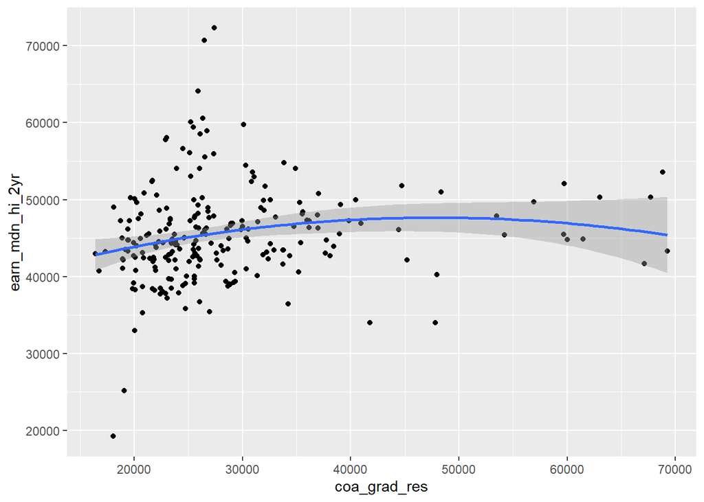

```r
df_socialwork %>%  ggplot(aes(x=coa_grad_res, y=earn_mdn_hi_2yr)) + geom_point() + stat_smooth(method = 'lm', formula = y ~ x + I(x^2), size = 1)
```

# 3 Population linear regression model

## 3.1 Purpose of Regression

- Regression analysis is a statistical method that helps us analyze and understand the relationship between 2+ variables
- What is the purpose of regression in **descriptive research** (sometimes called “observational studies” or “predictive” studies)?
  - To understand **relationship(s)** between one dependent variable (Y) to one or more indepedent variable (X, Z, etc.)
  - Not concerned with “direction” or “cause”: Does X cause Y? Does Y cause X?
  - Interested in “prediction”
  - Example: predict poverty status based on having a cell phone
- What is the purpose of regression in **econometrics research** (sometimes called “causal studies”)?
  - To estimate the **causal** effect of an independent variable (X) on a dependent variable (Y)
  - Very concerned with “direction” or “cause”: Does X cause Y?
  - Interested in recreating experimental conditions or what would have happened under a randomized control trial
  - Example: What is the effect of class size on student learning?
- Most of my research is descriptive; but I teach this class in a “causal” way… why?
  - One type of research is not better than the other; it’s just really important to understand the difference. *Ex: Lack of a cell phone doesn’t cause poverty!*
  - Causal research forces you to be very purposeful about your models!
  - Policy makers/decision makers don’t just care if there is a relationship between class size and student learning; they want to know if we decrease class size by two students what is the causal effect on student achievement

**Regression: Models, Variables, Relationships**

- **Linear Regression Model vs Non-Linear Regression Models**
  - Linear regression model (general linear model)
    - the dependent variable is continuous
    - e.g., GPA, test scores, income
    - **the focus of this class!**
  - Non-linear regression models (logit, ordinal, probit, poisson, negative binomial)
    - the dependent variable is non-continuous (i.e., categorical, binary, counts)
    - e.g., persistence, likert scales, type of major
- **Bivariate vs Multivariate Regression**
  - Bivariate regression (sometimes also called univariate, simple regression)
    - One dependent variable (Y) and one independent variable of interest ($X_1$)
  - Multivariate regression (for econometrics/causal inference)
    - One dependent variable (Y) and one independent variable of interest ($X_1$); **and** multiple control variables ($X_2$,$X_3$,$X_4$,etc.)
- **Linear Relationship vs Non-Linear Relationship between X and Y**
  - We will focus on modeling linear relationship between X and Y
  - we will cover non-linear relationships at end of quarter if we have time

## 3.2 Population Linear Regression Model

**Population** Linear Regression Model

- $Y_i = \beta_0 + \beta_1X_i + u_i$

Where:

- subscript $i$ refers to “units”; in our example, each unit $i$ is a university
- $Y_i$ = depenent variable of interest for unit $i$; institution-level student debt at university i
- $X_i$ = independent variable for unit $i$; cost of attendance at university i
- $\beta_0$ (“population intercept”) = represents average value of $Y$ (institution-level student debt) at a university with X=0 (cost of attendance = 0)
- $\beta_1$ (“population regression coefficient”) = average effect of a one-unit increase in X on the value of Y
- $u_1$ (“error term” or “residual”)
  - as “residual”, difference between predicted value and observed value
  - as “error term”, all other variables not included in your model that affect the value of Y

Draw Picture

```r
df_socialwork %>%  ggplot(aes(x=coa_grad_res, y=debt_all_stgp_eval_mean)) + geom_point() + stat_smooth(method = 'lm')
```

**Population** Linear Regression Model

$Y_i = \beta_0 + \beta_1X_i + u_i$

Called the “population” linear regression model because the model uses population parameters (which we usually do not know)

In particular, above model contains two population parameters

- $\beta_0$ (“population intercept”) = average value of $Y$ when $X=0$
- $\beta_1$ (“population regression coefficient”) = average effect of a one-unit increase in X on the value of Y
- How do we know these are population parameters?
  - because they use greek letters without a “hat” symbol
- Do we usually know the value of $\beta_0$ or $\beta_1$?
  - no. we estimate these population parameters using data from a sample

### 3.2.1 Population regression coefficient, $\beta_1$

When using regression to estimate causal relationship between $X$ and $Y$, the primary thing we are interested in estimating is $\beta_1$, which can be thought of the “slope” of the relationship between X and Y

**“Slope” Measures relationship between X and Y**

- Research Question
  - What is the effect of cost of attendance (X) on institution-level student debt (Y)
- What do we want to measure?
  - The relationship between cost of attendance (X) and institution-level student debt (Y)
  - If we increase the number of cost of attendance per week by $1,000, how much do we expect institution-level student debt to change?
- We want to measure $\beta$
  - $\beta = \frac{(Y_2 - Y_1)}{(X_2 - X_1)} = \frac{\Delta Y}{\Delta X}$
  - In other words, the slope of the relationship between X and Y
  - Under the assumption of a linear relationship

What is the population regression coefficient, $\beta_1$?

```r
df_socialwork %>%  ggplot(aes(x=coa_grad_res, y=debt_all_stgp_eval_mean)) + geom_point() + stat_smooth(method = 'lm')
```

Interpretation of $\beta_1$ (we will use this all semester!)

- General interpretation $\beta_1$:
  - On average, a one-unit increase in X is associated with a $\beta_1$ increase (or decrease) in the value of Y
  - (*note*. this works if $X$ is a continuous variable and if $X$ is dichotomous (2-category) variable like treatment vs. control)
- Interpretation from example above $\beta_1=1.5$:
  - On average, a $1 increase in cost of attendance (X) is associated with a $1.5 increase in institution-level student debt (Y)

Some important things to remember:

- If $\beta_1$ (i.e., the relationship between X and Y) is linear, then the average change in Y for a one-unit increase in X is the same no matter the starting value of X
  - Like plot example from earlier
- $\beta_1$ measures the **average** effect on Y for a one-unit increase in X; this effect on an individual observation may be different than this average effect!
- $\beta_1$ is a population parameter. We hardly ever know population parameters. So we **estimate** $\beta_1$ using sample data!

### 3.2.2 Population Intercept, $\beta_0$

Population linear regression model

- $Y_i = \beta_0 + \beta_1X_i + u_i$

$\beta_0$ is the “population intercept”

- $\beta_0$ = the average value of Y when X=0
- Here, $\beta_0$, is the average value of institution-level student debt at a university where cost of attendance equals $0 (X=0)
- Usually, we are not substantively interested in $\beta_0$, but we need the intercept to draw a regression line
- Sometimes $\beta_0$ is non-sensical or there’s too few observations at X=0 to calculate a precise estimate
  - for our research question and data, there are no universities where grad school cost of attendance is zero, so we can’t really make any predictions (based on real data) about what institution-level student debt would be if cost of attendance is zero

- note: not to scale

```r
df_socialwork %>%  ggplot(aes(x=coa_grad_res, y=debt_all_stgp_eval_mean)) + geom_point() + stat_smooth(method = 'lm')
```

### 3.2.3 Population Linear Regression Line

**Population** Linear Regression Model

- $Y_i = \beta_0 + \beta_1X_i + u_i$

We sometimes deconstruct the Population Linear Regression Model into two parts:

1. **Population** Linear Regression *LINE*: $Y_i = \beta_0 + \beta_1X_i$
   - sometimes called population linear regression function
2. **Population** “Error” or “Residual” Term: $u_i$
- Population regression line: just a linear prediction line, like the one in the scatterplot *if* the scatterplot contained all observation in the population
- Population regression line measures the “average” or “expected” relationship between X and Y, ignoring variables that we excluded from the model (i.e., $u_i$)

```r
df_socialwork %>%  ggplot(aes(x=coa_grad_res, y=debt_all_stgp_eval_mean)) + geom_point() + stat_smooth(method = 'lm')
```

**Population regression line and Expected Value, E(Y)**

- Expected value of Y (one variable)
  - $E(Y) = \mu_Y$
  - in words: expected value of variable $Y$ equals the population mean value of variable $Y$
- Expected value of Y, given the value of X (conditional expectation; relationship between two variables)
  - $E(Y|X) = \beta_0 + \beta_1X_i$
  - the population regression line is expected value of Y for a given value of X
- Population regression line and prediction
  - If we know value of parameters, $\beta_0$ and $\beta_1$, we can predict value of Y
  - Example: imagine $\beta_0=\$10,000$ and $\beta_1=\$1.5$
  - 1. Predict the value of Y (institution-level student debt) for university where cost of attendance is $20K
    - $E(Y|X) = \beta_0 + \beta_1X_i= 10,000 + 1.5 \times 20,000= 40,000$
  - 2. Predict the value of Y (institution-level student debt) for university where cost of attendance is $40K
    - $E(Y|X) = \beta_0 + \beta_1X_i= 10,000 + 1.5 \times 40,000= 40,000 = 70,000$

### 3.2.4 $u_i$

**$u_i$ as “Error Term” or “unobserved variables”**

- Population linear regression model
  - $Y_i = \beta_0 + \beta_1X_i + u_i$
  - Y= institution-level student debt; $X_i$= cost of attendance
- In causal inference research:
  - Error term $u_i$ represents (consists of) *all other variables besides X that are not included in your model* that affect the dependent variable
  - In other words, the error term consists of all other factors (i.e., variables), aside from $X$= cost of attendance, responsible for the difference between the actual institution-level student debt at university $i$ and the value for university $i$ that is predicted by the regression line
  - This interpretation will become *super* important down the road!
- Example of Y= institution-level student debt; $X_i$= cost of attendance; the error term $u_i$ would consist of other factors besides cost of attendance that have an effect on institution-level student debt
  - cost of healthcare; whether students can rely on parents to pay for graduate school; how much grant aid students are awarded
- In other social science based statistics classes (outside of the discipline of economics)
  - Interpret the $u_i$ as the overall error in the prediction of Y due to *random variation*

**Thinking about $u_i$ as “Residual”**

# 4 Regression in R

Conceptually, the next step in learning about regression is understanding how we choose estimates of $\beta_0$ and $\beta_1$ using sample data? This step is called “estimation”

Before providing a conceptual explanation of estimation, we will teach you about running regression in *R*. Then, we’ll use output from these regression models to aid our conceptual explanation of estimation

## 4.1 run models using `lm()`

We use the `lm()` function to run linear regression models

`lm()` function

- Description
  - “`lm` is used to fit linear models”
- syntax (including default values)
  - `lm(formula, data, subset, weights, na.action, method = "qr", model = TRUE, x = FALSE, y = FALSE, qr = TRUE, singular.ok = TRUE, contrasts = NULL, offset, ...)`
- selected arguments
  - `formula`: “an object of class ‘formula’” that provides “a symbolic description of the model to be fitted.”
    - follows form `formula = y_var ~ x_var1 + x_var2+ x_var3`
    - where `y_var` is the outcome variable and `x_var`s are independent variables
  - `data`: data frame that contains variables named in `formula`
  - `subset`: “an optional vector specifying a subset of observations to be used in the fitting process.”
  - `na.action`: “a function which indicates what should happen when the data contain NAs”
    - by default, an observation will be excluded from the model if itcontains missing values for any variable used in the model
- Value (object created or “returned” by the `lm()` function)
  - “lm returns an object of class ‘lm’”
  - “An object of class ‘lm’ is a list containing at least the following components”

Run model of the relationship between cost of attendance (X) and institution-level student debt (Y)

- However, the output printed just by running the `lm()` function usually doesn’t contain everything we need

```r
lm(formula = debt_all_stgp_eval_mean ~ coa_grad_res, data = df_socialwork)
```

```
#>
#> Call:
#> lm(formula = debt_all_stgp_eval_mean ~ coa_grad_res, data = df_socialwork)
#>
#> Coefficients:
#>  (Intercept)  coa_grad_res
#>   13445.9395        0.9687
```

When you run the `lm()` function, *R* creates an object that contains lots of information about the model we run. We can store this object by assigning it a name using `<-`

- let’s store the object

```r
# create object
mod1 <- lm(formula = debt_all_stgp_eval_mean ~ coa_grad_res, data = df_socialwork)

# simple print of mod1 object
mod1
```

```
#>
#> Call:
#> lm(formula = debt_all_stgp_eval_mean ~ coa_grad_res, data = df_socialwork)
#>
#> Coefficients:
#>  (Intercept)  coa_grad_res
#>   13445.9395        0.9687
```

Let’s investigate the contents of the `mod1` object using the `str()` function

```r
# investigate contents of mod1 object using str() function
mod1 %>% str()
```

```
#> List of 12
#>  $ coefficients : Named num [1:2] 13445.94 0.969
#>   ..- attr(*, "names")= chr [1:2] "(Intercept)" "coa_grad_res"
#>  $ residuals    : Named num [1:253] 16173 3626 -8549 1455 -2863 ...
#>   ..- attr(*, "label")= chr "Average Stafford and Grad PLUS loan debt disbursed at this institution"
#>   ..- attr(*, "names")= chr [1:253] "1" "2" "3" "4" ...
#>  $ effects      : Named num [1:253] -653487 150598 -9495 619 -3953 ...
#>   ..- attr(*, "label")= chr "Average Stafford and Grad PLUS loan debt disbursed at this institution"
#>   ..- attr(*, "names")= chr [1:253] "(Intercept)" "coa_grad_res" "" "" ...
#>  $ rank         : int 2
#>  $ fitted.values: Named num [1:253] 35615 34375 41379 47823 32935 ...
#>   ..- attr(*, "label")= chr "Average Stafford and Grad PLUS loan debt disbursed at this institution"
#>   ..- attr(*, "names")= chr [1:253] "1" "2" "3" "4" ...
#>  $ assign       : int [1:2] 0 1
#>  $ qr           :List of 5
#>   ..$ qr   : num [1:253, 1:2] -15.906 0.0629 0.0629 0.0629 0.0629 ...
#>   .. ..- attr(*, "dimnames")=List of 2
#>   .. .. ..$ : chr [1:253] "1" "2" "3" "4" ...
#>   .. .. ..$ : chr [1:2] "(Intercept)" "coa_grad_res"
#>   .. ..- attr(*, "assign")= int [1:2] 0 1
#>   ..$ qraux: num [1:2] 1.06 1.04
#>   ..$ pivot: int [1:2] 1 2
#>   ..$ tol  : num 0.0000001
#>   ..$ rank : int 2
#>   ..- attr(*, "class")= chr "qr"
#>  $ df.residual  : int 251
#>  $ xlevels      : Named list()
#>  $ call         : language lm(formula = debt_all_stgp_eval_mean ~ coa_grad_res, data = df_socialwork)
#>  $ terms        :Classes 'terms', 'formula'  language debt_all_stgp_eval_mean ~ coa_grad_res
#>   .. ..- attr(*, "variables")= language list(debt_all_stgp_eval_mean, coa_grad_res)
#>   .. ..- attr(*, "factors")= int [1:2, 1] 0 1
#>   .. .. ..- attr(*, "dimnames")=List of 2
#>   .. .. .. ..$ : chr [1:2] "debt_all_stgp_eval_mean" "coa_grad_res"
#>   .. .. .. ..$ : chr "coa_grad_res"
#>   .. ..- attr(*, "term.labels")= chr "coa_grad_res"
#>   .. ..- attr(*, "order")= int 1
#>   .. ..- attr(*, "intercept")= int 1
#>   .. ..- attr(*, "response")= int 1
#>   .. ..- attr(*, ".Environment")=<environment: R_GlobalEnv>
#>   .. ..- attr(*, "predvars")= language list(debt_all_stgp_eval_mean, coa_grad_res)
#>   .. ..- attr(*, "dataClasses")= Named chr [1:2] "numeric" "numeric"
#>   .. .. ..- attr(*, "names")= chr [1:2] "debt_all_stgp_eval_mean" "coa_grad_res"
#>  $ model        :'data.frame':   253 obs. of  2 variables:
#>   ..$ debt_all_stgp_eval_mean: num [1:253] 51788 38001 32830 49278 30072 ...
#>   .. ..- attr(*, "label")= chr "Average Stafford and Grad PLUS loan debt disbursed at this institution"
#>   ..$ coa_grad_res           : num [1:253] 22886 21606 28836 35488 20119 ...
#>   .. ..- attr(*, "label")= chr "graduate, full-time, state resident COA; == tuition + fees + (ug) books/supplies + (ug) off-campus room and boa"| __truncated__
#>   ..- attr(*, "terms")=Classes 'terms', 'formula'  language debt_all_stgp_eval_mean ~ coa_grad_res
#>   .. .. ..- attr(*, "variables")= language list(debt_all_stgp_eval_mean, coa_grad_res)
#>   .. .. ..- attr(*, "factors")= int [1:2, 1] 0 1
#>   .. .. .. ..- attr(*, "dimnames")=List of 2
#>   .. .. .. .. ..$ : chr [1:2] "debt_all_stgp_eval_mean" "coa_grad_res"
#>   .. .. .. .. ..$ : chr "coa_grad_res"
#>   .. .. ..- attr(*, "term.labels")= chr "coa_grad_res"
#>   .. .. ..- attr(*, "order")= int 1
#>   .. .. ..- attr(*, "intercept")= int 1
#>   .. .. ..- attr(*, "response")= int 1
#>   .. .. ..- attr(*, ".Environment")=<environment: R_GlobalEnv>
#>   .. .. ..- attr(*, "predvars")= language list(debt_all_stgp_eval_mean, coa_grad_res)
#>   .. .. ..- attr(*, "dataClasses")= Named chr [1:2] "numeric" "numeric"
#>   .. .. .. ..- attr(*, "names")= chr [1:2] "debt_all_stgp_eval_mean" "coa_grad_res"
#>  - attr(*, "class")= chr "lm"
```

Let’s play around with the element named `coefficients` within the object `mod1` using the syntax `object_name$element_name`

```r
# names of elements in object mod1
names(mod1)
```

```
#>  [1] "coefficients"  "residuals"     "effects"       "rank"          "fitted.values" "assign"        "qr"            "df.residual"   "xlevels"       "call"          "terms"         "model"
```

```r
# mod1$coefficients

  #print element
    mod1$coefficients
```

```
#>   (Intercept)  coa_grad_res
#> 13445.9395041     0.9686902
```

```r
  #investigate structure of element
    # a (named) numeric vector
    mod1$coefficients %>% str()
```

```
#>  Named num [1:2] 13445.94 0.969
#>  - attr(*, "names")= chr [1:2] "(Intercept)" "coa_grad_res"
```

```r
    str(mod1$coefficients) # same same
```

```
#>  Named num [1:2] 13445.94 0.969
#>  - attr(*, "names")= chr [1:2] "(Intercept)" "coa_grad_res"
```

```r
  # names of element
    mod1$coefficients %>% names()
```

```
#> [1] "(Intercept)"  "coa_grad_res"
```

```r
    names(mod1$coefficients) # same same
```

```
#> [1] "(Intercept)"  "coa_grad_res"
```

```r
  # length of element
    mod1$coefficients %>% length()
```

```
#> [1] 2
```

```r
    length(mod1$coefficients) # same same
```

```
#> [1] 2
```

```r
# so the mod1$coefficients is an object itself; it is a numeric vector of length=2

  # print the first element of mod1$coefficients
  mod1$coefficients[1]
```

```
#> (Intercept)
#>    13445.94
```

```r
  # print the second element of mod1$coefficients
  mod1$coefficients[2]
```

```
#> coa_grad_res
#>    0.9686902
```

A key takeaway from above code chunk

- Population linear regression model
  - $Y_i = \beta_0 + \beta_1X_i + u_i$
- Our estimate of $\beta_0$ can be found by typing `mod1$coefficients[1]`
  - 13445.9395041
- Our estimate of $\beta_1$ can be found by typing `mod1$coefficients[2]`
  - 0.9686902

## 4.2 `summary()` function

Use the `summary()` after use running `lm()` to produce easier-to-read summary of regression results

`summary()` function

- Description
  - “summary is a generic function used to produce result summaries of the results of various model fitting functions. The function invokes particular methods which depend on the class of the first argumen”
- syntax
  - `summary(object, ...)`
  - examples (these give the same result)
    - `summary(object = mod1)`
    - `summary(mod1)`
- Value (object created or “returned” by the `summary()` function)
  - object returned by the summary function is different depending on the kind of model you are summarizing

Run `summary()` function after running regression using `lm()`

```r
mod1 <- lm(formula = debt_all_stgp_eval_mean ~ coa_grad_res, data = df_socialwork)

# priting output from summary(mod1)
  #summary(object = mod1)
  summary(mod1)
```

```
#>
#> Call:
#> lm(formula = debt_all_stgp_eval_mean ~ coa_grad_res, data = df_socialwork)
#>
#> Residuals:
#>    Min     1Q Median     3Q    Max
#> -25799  -5991   -926   5357  42453
#>
#> Coefficients:
#>                 Estimate  Std. Error t value             Pr(>|t|)
#> (Intercept)  13445.93950  1830.24898   7.347     0.00000000000285 ***
#> coa_grad_res     0.96869     0.06069  15.962 < 0.0000000000000002 ***
#> ---
#> Signif. codes:  0 '***' 0.001 '**' 0.01 '*' 0.05 '.' 0.1 ' ' 1
#>
#> Residual standard error: 9435 on 251 degrees of freedom
#> Multiple R-squared:  0.5038, Adjusted R-squared:  0.5018
#> F-statistic: 254.8 on 1 and 251 DF,  p-value: < 0.00000000000000022
```

Using `str()` to investigate object created by `summary()` function

```r
# investigating object created by summary(mod1)
summary(mod1) %>% str()
```

```
#> List of 11
#>  $ call         : language lm(formula = debt_all_stgp_eval_mean ~ coa_grad_res, data = df_socialwork)
#>  $ terms        :Classes 'terms', 'formula'  language debt_all_stgp_eval_mean ~ coa_grad_res
#>   .. ..- attr(*, "variables")= language list(debt_all_stgp_eval_mean, coa_grad_res)
#>   .. ..- attr(*, "factors")= int [1:2, 1] 0 1
#>   .. .. ..- attr(*, "dimnames")=List of 2
#>   .. .. .. ..$ : chr [1:2] "debt_all_stgp_eval_mean" "coa_grad_res"
#>   .. .. .. ..$ : chr "coa_grad_res"
#>   .. ..- attr(*, "term.labels")= chr "coa_grad_res"
#>   .. ..- attr(*, "order")= int 1
#>   .. ..- attr(*, "intercept")= int 1
#>   .. ..- attr(*, "response")= int 1
#>   .. ..- attr(*, ".Environment")=<environment: R_GlobalEnv>
#>   .. ..- attr(*, "predvars")= language list(debt_all_stgp_eval_mean, coa_grad_res)
#>   .. ..- attr(*, "dataClasses")= Named chr [1:2] "numeric" "numeric"
#>   .. .. ..- attr(*, "names")= chr [1:2] "debt_all_stgp_eval_mean" "coa_grad_res"
#>  $ residuals    : Named num [1:253] 16173 3626 -8549 1455 -2863 ...
#>   ..- attr(*, "label")= chr "Average Stafford and Grad PLUS loan debt disbursed at this institution"
#>   ..- attr(*, "names")= chr [1:253] "1" "2" "3" "4" ...
#>  $ coefficients : num [1:2, 1:4] 13445.9395 0.9687 1830.249 0.0607 7.3465 ...
#>   ..- attr(*, "dimnames")=List of 2
#>   .. ..$ : chr [1:2] "(Intercept)" "coa_grad_res"
#>   .. ..$ : chr [1:4] "Estimate" "Std. Error" "t value" "Pr(>|t|)"
#>  $ aliased      : Named logi [1:2] FALSE FALSE
#>   ..- attr(*, "names")= chr [1:2] "(Intercept)" "coa_grad_res"
#>  $ sigma        : num 9435
#>  $ df           : int [1:3] 2 251 2
#>  $ r.squared    : num 0.504
#>  $ adj.r.squared: num 0.502
#>  $ fstatistic   : Named num [1:3] 255 1 251
#>   ..- attr(*, "names")= chr [1:3] "value" "numdf" "dendf"
#>  $ cov.unscaled : num [1:2, 1:2] 0.0376335913301 -0.0000011804756 -0.0000011804756 0.0000000000414
#>   ..- attr(*, "dimnames")=List of 2
#>   .. ..$ : chr [1:2] "(Intercept)" "coa_grad_res"
#>   .. ..$ : chr [1:2] "(Intercept)" "coa_grad_res"
#>  - attr(*, "class")= chr "summary.lm"
```

```r
summary(mod1)$coefficients
```

```
#>                   Estimate    Std. Error   t value                                         Pr(>|t|)
#> (Intercept)  13445.9395041 1830.24898197  7.346508 0.0000000000028486699404211586288820923229536675
#> coa_grad_res     0.9686902    0.06068575 15.962400 0.0000000000000000000000000000000000000004558158
```

```r
summary(mod1)$coefficients %>% str()
```

```
#>  num [1:2, 1:4] 13445.9395 0.9687 1830.249 0.0607 7.3465 ...
#>  - attr(*, "dimnames")=List of 2
#>   ..$ : chr [1:2] "(Intercept)" "coa_grad_res"
#>   ..$ : chr [1:4] "Estimate" "Std. Error" "t value" "Pr(>|t|)"
```

Grabbing individual elements from `summary(mod1)$coefficients`

- the element “coefficients” created by summary() is a “matrix”
- more specifically, it is a 2 X 4 matrix, that is a matrix with 2 rows and 4 columns
- we can grab an individual cell within the matrix using this syntax: `summary(mod1)$coefficients[<row_num>,<col_num]`
  - e.g., type `summary(mod1)$coefficients[2,1]` to print estimate of $\beta_1$
  - like this: 0.9686902

```r
# the element "coefficients" created by summary() is a "matrix"
summary(mod1)$coefficients %>% class()
```

```
#> [1] "matrix" "array"
```

```r
# more specifically, it is a 2 X 4 matrix, that is a matrix with 2 rows and 4 columns
summary(mod1)$coefficients %>% str()
```

```
#>  num [1:2, 1:4] 13445.9395 0.9687 1830.249 0.0607 7.3465 ...
#>  - attr(*, "dimnames")=List of 2
#>   ..$ : chr [1:2] "(Intercept)" "coa_grad_res"
#>   ..$ : chr [1:4] "Estimate" "Std. Error" "t value" "Pr(>|t|)"
```

```r
# we can grab an individual cell within the matrix using this syntax:
  # summary(mod1)$coefficients[<row_num>,<col_num]
  summary(mod1)$coefficients[2,1] # this is the estimate for Beta_1
```

```
#> [1] 0.9686902
```

# 5 Estimation

**General things we do in regression analysis**

1. **Estimation** [Today]
   - How do we choose estimates of $\beta_0$ and $\beta_1$ using sample data?
2. **Prediction** [Next Week]
   - What is the predicted value of Y for someone with a particular value of X?
3. **Hypothesis testing** [focus of the rest of the semester]
   - Hypothesis testing and confidence intervals about $\beta_1$

Step 1 of regression is to estimate parameters of the population linear regression model

- $Y_i = \beta_0 + \beta_1X_i + u_i$

**Goal of estimation: use sample data to estimate population parameters**:

- Previous lecture: we used sample data on variable $Y$ to estimate population mean, $\mu_Y$
  - $\bar{Y}$ (sample mean of $Y$) is an estimate of $\mu_Y$
- This lecture: use sample data to estimate the population intercept, $\beta_0$, and the population regression coefficient, $\beta_1$
  - $\hat{\beta_0}$ is an estimate of $\beta_0$
  - $\hat{\beta_1}$ is an estimate of $\beta_1$

**Review of terms**

- *point estimate (also called “estimate”)*:
  - a single value that is our guess of the value of the population parameter
  - e.g., sample mean institution-level student debt $\bar{Y}=$ 41084 is our best guess of population mean institution-level student debt $\mu_Y$
- *estimator*:
  - a method or formula for calculating an estimate of a population parameter based on sample data
  - e.g., $\bar{Y} = \frac{\sum_{i=1}^{n} Y_i}{n}$ is estimator (formula) for calculating an estimate of population mean, $\mu_Y$
- *estimation*:
  - the process of using an estimator to calculate point estimates of population parameters, based on sample data

**Estimation problem**:

- we write out the population linear regression model, $Y_i = \beta_0 + \beta_1X_i + u_i$
- Need to develop a method for choosing values of $\hat{\beta_0}$ and $\hat{\beta_1}$
  - that is we need to develop an estimator that yields the “best” point estimates of $\hat{\beta_0}$ and $\hat{\beta_1}$

## 5.1 Estimation (population mean)

We faced a similar estimation problem when we were trying to estimate population mean, $\mu_Y$!

- Using sample data, we want to calculate the “best” estimate of the population mean, $\mu_Y$
- We decided sample mean, $\bar{Y}= \frac{\sum_{i=1}^{n} Y_i}{n}$, was the “best” estimate

**How did statisticians decide that $\bar{Y}= \frac{\sum_{i=1}^{n} Y_i}{n}$ was “best” estimate of $\mu_Y$? What criteria to make this decision?:**

imagine that $m$ is all potential estimates for $\mu_Y$

- e.g., $\bar{Y}$ is one potential estimate of $\mu_Y$; the sample median is another potential estimate

Criteria statisticians used to decide which $m$ is the “best” estimate of $\mu_Y$:

- choose the value, $m$ , that minimizes the “sum of squares”
- Sum of squares = $\sum_{i=1}^{n}(Y_i-m)^2$
- Sum of squares in words
  - for each observation: measures how far away an individual observation $Y_i$ is from estimate $m$; and then square this distance (to remove negative values)
  - then sum this squared distance across all observations, $Y_i$
- Conceptually, in choosing “minimize sum of squares” as our criteria for selecting the best estimate of $\mu_Y$, we are “how far off” in total (across all observations) if we can only use a single value to be our guess of the value of each individual observation

Below, we graph scatterplot of cost of attendance (X) and institution-level student debt (Y axis), and add a horizontal line for the mean value of institution-level student debt, $\bar{Y}=$ 41084

- let’s say that $\bar{Y}=$ 41084 is our “predicted value” for each observation in the scatterplot
- For each observation $i$, the “residual” $u_i = Y_i - \bar{Y}$ represents how far off our predicted value is from the actual value for that observation
- $\bar{Y}= \frac{\sum_{i=1}^{n} Y_i}{n}$ is the choice for $m$ that minimizes the sum of squared errors, $\sum_{i=1}^{n}(Y_i-m)^2$
- in other words, $\bar{Y}$ is the value that minimizes how far off our prediction is in total (across all observations)

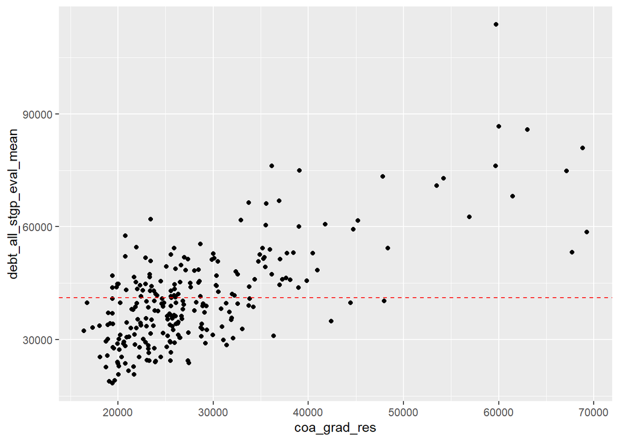

```r
#df_socialwork %>%  ggplot(aes(x=coa_grad_res, y=debt_all_stgp_eval_mean)) + geom_point() + stat_smooth(method = 'lm')
df_socialwork %>%  ggplot(aes(x=coa_grad_res, y=debt_all_stgp_eval_mean)) + geom_point() +
  geom_hline(yintercept=mean(df_socialwork$debt_all_stgp_eval_mean, na.rm = TRUE), linetype="dashed", color = "red")
```

## 5.2 Estimation (regression)

Population linear regression model

- $Y_i = \beta_0 + \beta_1X_i + u_i$

The estimation problem in regression

- Need to develop method for selecting the “best” estimate of $\hat{\beta_0}$ and $\hat{\beta_1}$
- Solution: do the same thing we did for population mean! Choose the estimates $\hat{\beta_0}$ and $\hat{\beta_1}$ that minimize the sum of squares

First some terminology:

- $Y_i$ is the actual observed value of $Y$ for observation $i$
- $\hat{\beta_0}$ is an estimate of $\beta_0$, population average value of $Y$ when $X=0$
- $\hat{\beta_1}$ is an estimate of $\beta_1$, the average change in the value of $Y$ associated with a one-unit increase in $X$
- $\hat{Y_i}$ is the predicted value of $Y_i$, based on sample data!
  - $\hat{Y_i} = \hat{\beta_0} + \hat{\beta_1}X_i$
  - Example: $\hat{\beta_0}=10,000$ and $\hat{\beta_1}=.75$, then for a university with cost of attendance = $30,000$
    - $\hat{Y_i} = \hat{\beta_0} + \hat{\beta_1}X_i = 10,000 + .75 \times30,000=32,500$
- Estimated residual, $\hat{u}_i$ is the difference between actual $Y_i$ and predicted $\hat{Y_i}$
  - $Y_i - \hat{Y_i}$ = $\hat{u_i}$
  - $Y_i - (\hat{\beta_0} + \hat{\beta_1}X_i)$ = $\hat{u_i}$
  - Residuals are often called “errors”

Criteria for choosing “best” estimate of $\hat{\beta_0}$ and $\hat{\beta_1}$

- Select values that minimize “sum of squared residuals”
- that is, the “best” estimates of $\hat{\beta_0}$ and $\hat{\beta_1}$ are those that any other alternatives would result in a higher sum of squared residuals

Sum of squared residuals (or sometimes called “sum of squared errors”):

- $\sum_{i=1}^{n}$ $(Y_i - \hat{Y_i})^2$
- $\sum_{i=1}^{n}$ $(Y_i - (\hat{\beta_0} + \hat{\beta_1}X_i))^2$
- $\sum_{i=1}^{n}$ $(u_i)^2$

Conceptual explanation for use “sum of squared residuals” as the criteria for choosing values for $\hat{\beta_0}$ and $\hat{\beta_1}$

- Having a y-intercept ($\hat{\beta_0}$) and a slope ($\hat{\beta_1}$) allows us to draw a straight line, our “prediction line”
- by choosing the values of $\hat{\beta_0}$ and $\hat{\beta_1}$ that minimize the sum of squared residuals, we are creating a linear prediction line that minimizes how far away (in total, across all observations) the predicted values are from the actual values

Scatterplot of cost of attendance (X) and institution-level student debt (Y)

```r
df_socialwork %>%  ggplot(aes(x=coa_grad_res, y=debt_all_stgp_eval_mean)) + geom_point() +
  stat_smooth(method = 'lm') +
  geom_hline(yintercept=mean(df_socialwork$debt_all_stgp_eval_mean, na.rm = TRUE), linetype="dashed", color = "red")
```

[output not shown]

**Ordinary Least Squares (OLS) Estimator** is a linear method for estimating parameters in a linear regression model based on the sum of squared errors criterion

- Method draws a line through the sample data points that minimizes the sum of squared residuals, or in other words, the differences between the observed values and the corresponding fitted values
- Minimization is achieved via calculus (derivatives). R will calculate this for you (phew!)
- $\hat{\beta_0}$ and $\hat{\beta_1}$, respectively, are the symbols for the OLS estimates of population parameters $\beta_0$ and $\beta_1$

### 5.2.1 OLS Prediction Line

RQ: What is the effect of cost of attendance (X) on institution-level student debt (Y)?

**Population Linear Regression Model**

- $Y_i = \beta_0 + \beta_1X_i + u_i$

**OLS Prediction Line or “OLS Regression Line” (based on sample data)**

- $\hat{Y_i} = \hat{\beta_0} + \hat{\beta_1}X_i$

Let’s run regression in R using `lm()` to calculate values for point estimates $\hat{\beta_0}$ and $\hat{\beta_1}$

- $\hat{\beta_0}=$ 13445.94
- $\hat{\beta_1}=$ 0.97

```r
mod1 <- lm(formula = debt_all_stgp_eval_mean ~ coa_grad_res, data = df_socialwork)

summary(mod1)
```

```
#>
#> Call:
#> lm(formula = debt_all_stgp_eval_mean ~ coa_grad_res, data = df_socialwork)
#>
#> Residuals:
#>    Min     1Q Median     3Q    Max
#> -25799  -5991   -926   5357  42453
#>
#> Coefficients:
#>                 Estimate  Std. Error t value             Pr(>|t|)
#> (Intercept)  13445.93950  1830.24898   7.347     0.00000000000285 ***
#> coa_grad_res     0.96869     0.06069  15.962 < 0.0000000000000002 ***
#> ---
#> Signif. codes:  0 '***' 0.001 '**' 0.01 '*' 0.05 '.' 0.1 ' ' 1
#>
#> Residual standard error: 9435 on 251 degrees of freedom
#> Multiple R-squared:  0.5038, Adjusted R-squared:  0.5018
#> F-statistic: 254.8 on 1 and 251 DF,  p-value: < 0.00000000000000022
```

```r
summary(mod1)$coefficients %>% class()
```

```
#> [1] "matrix" "array"
```

```r
# more specifically, it is a 2 X 4 matrix, that is a matrix with 2 rows and 4 columns
summary(mod1)$coefficients %>% str()
```

```
#>  num [1:2, 1:4] 13445.9395 0.9687 1830.249 0.0607 7.3465 ...
#>  - attr(*, "dimnames")=List of 2
#>   ..$ : chr [1:2] "(Intercept)" "coa_grad_res"
#>   ..$ : chr [1:4] "Estimate" "Std. Error" "t value" "Pr(>|t|)"
```

```r
# we can grab an individual cell within the matrix using this syntax:
  # summary(mod1)$coefficients[<row_num>,<col_num]
  summary(mod1)$coefficients[1,1] # row 1, column 1; this is the estimate for Beta_0
```

```
#> [1] 13445.94
```

```r
  summary(mod1)$coefficients[2,1] # row 2, column 1; this is the estimate for Beta_1
```

```
#> [1] 0.9686902
```

## 5.3 Writing out models

When we run a regression model, write out regression models like this (we will be doing this the rest of the quarter):

- Write out the population linear regression model
  - Label symbols; label what the variables $X$ and $Y$ actually represent
- OLS prediction line
  - write out OLS prediction line without estimate values
  - write out OLS prediction line with estimate values
- And usually a good idea to:
  - write out interpretation of$\hat{\beta_0}$ in words
  - write out interpretation of$\hat{\beta_1}$ in words
- **Population Linear Regression Model**
  - $Y_i = \beta_0 + \beta_1X_i + u_i$
  - where:
    - subscript $i$ refers to universities
    - $Y_i$: institution-level student debt (in dollars) at university $i$
    - $X_i$: annual cost of attendance (in dollars) for full-time resident graduate students at university $i$
    - $\beta_0$: population intercept, average value of $Y$ when $X=0$
    - $\beta_1$: population regression coefficient, the average change in the value of $Y$ associated with a one-unit increase in $X$
  - **OLS Prediction Line or “OLS Regression Line” (based on sample data)**
  - $\hat{Y_i} = \hat{\beta_0} + \hat{\beta_1}X_i$
  - $\hat{Y_i} =$ 13445.94 + 0.97 $\times X_i$

Once you write it out like this, easy to answer questions about your regression model

- Predict the the expected value institution-level student debt at a university where annual cost of attendance is $20,000? That is, what is $E(\hat{Y_i}|X=20,000)$?
  - $E(\hat{Y_i}|X=20,000) = \hat{Y_i} = \hat{\beta_0} + \hat{\beta_1}X_i=$ 13445.94 + 0.97 $\times 20,000$ = 32820
- Predict the the expected value value of institution-level student debt at a university where annual cost of attendance is $50,000? That is, what is $E(\hat{Y_i}|X=50,000)$?
  - $E(\hat{Y_i}|X=50,000) = \hat{Y_i} = \hat{\beta_0} + \hat{\beta_1}X_i=$ 13445.94 + 0.97 $\times 50,000$ = 61880

Interpreting $\hat{\beta_0}$ and $\hat{\beta_1}$ in words

- $\hat{\beta_0}=$ 13445.94 is the OLS estimate of the population intercept $\beta_0$, which represents average value of $Y$ (institution-level student debt) at a university with X=0 (cost of attendance = 0)
  - interpretation of $\hat{\beta_0}=$ 13445.94: the predicted institution-level student debt at a university with annual cost of attendance equals `0` is 13445.94
- $\hat{\beta_1}=$ 0.97 is the OLS estimate of the population intercept $\beta_1$, which represents average effect of a one-unit increase in $X$ on the value of $Y$
  - General formula for interpretation of $\hat{\beta_1}$:
    - "On average, a one-unit increase in $X$ is associated with a $\hat{\beta_1}$ increase (or decrease) in the value of $Y$
    - when applying this formula replace “one unit increase in $X$” with “one dollar increase in annual cost of attendance”; do the same sort of thing for $Y$
  - interpretation of $\hat{\beta_1}=$ 0.97: a one-dollar increase in annual cost of attendance is associated with a 0.97 dollar increase in institution-level student debt

# 6 Model Fit

## 6.1 $R^2$

Introducing, $R^2$, “the coefficient of determination”

Reminder of where we left off:

- Research question
  - What is the relationship between cost of attendance ($X$) on institution-level student debt ($Y$)?
- Population Linear Regression Model
  - $Y_i = \beta_0 + \beta_1X_i + u_i$
  - where:
    - subscript $i$ refers to universities
    - $Y_i$: institution-level student debt (in dollars) at university $i$
    - $X_i$: annual cost of attendance (in dollars) for full-time resident graduate students at university $i$
    - $\beta_0$: population intercept, average value of $Y$ when $X=0$
    - $\beta_1$: population regression coefficient, the average change in the value of $Y$ associated with a one-unit increase in $X$
- OLS Prediction Line (based on sample data) $\hat{Y_i}$ is predicted value $Y_i$ for a given value of $X$
  - $\hat{Y_i} = \hat{\beta_0} + \hat{\beta_1}X_i$
  - $\hat{Y_i} =$ 13445.94 + 0.97 $\times X_i$

In the summary of the regression output below, notice the following:

- “Multiple R-squared:” 0.5038

```r
mod1 <- lm(formula = debt_all_stgp_eval_mean ~ coa_grad_res, data = df_socialwork)

summary(mod1)
```

```
#>
#> Call:
#> lm(formula = debt_all_stgp_eval_mean ~ coa_grad_res, data = df_socialwork)
#>
#> Residuals:
#>    Min     1Q Median     3Q    Max
#> -25799  -5991   -926   5357  42453
#>
#> Coefficients:
#>                 Estimate  Std. Error t value             Pr(>|t|)
#> (Intercept)  13445.93950  1830.24898   7.347     0.00000000000285 ***
#> coa_grad_res     0.96869     0.06069  15.962 < 0.0000000000000002 ***
#> ---
#> Signif. codes:  0 '***' 0.001 '**' 0.01 '*' 0.05 '.' 0.1 ' ' 1
#>
#> Residual standard error: 9435 on 251 degrees of freedom
#> Multiple R-squared:  0.5038, Adjusted R-squared:  0.5018
#> F-statistic: 254.8 on 1 and 251 DF,  p-value: < 0.00000000000000022
```

```r
#summary(mod1) %>% str() # show structure of object created by summary(mod1)

# print r-squared using syntax object_name$element_name
summary(mod1)$r.squared
```

```
#> [1] 0.5037547
```

**What does $R^2$ measure?**

- $R^2$, “the coefficient of determination”, measures the fraction of the variance in Y that is explained by X (and is not already explained by sample mean, $\bar{Y}$)
  - In other words, how much better is the regression model in predicting values of Y than $\bar{Y}$

- $R^2$, “the coefficient of determination”, measures how much closer the predicted values of $\hat{Y_i}$ are to actual values $Y_i$ when we use OLS prediction line to predict $Y_i$ (i.e., $\hat{Y_i}=\hat{\beta_0} + \hat{\beta_1}X_i$), rather than using sample mean $\bar{Y}$ to predict $Y_i$ (i.e., $\hat{Y_i}=\bar{Y}$)

```r
df_socialwork %>%  ggplot(aes(x=coa_grad_res, y=debt_all_stgp_eval_mean)) + geom_point() +
  stat_smooth(method = 'lm') +
  geom_hline(yintercept=mean(df_socialwork$debt_all_stgp_eval_mean, na.rm = TRUE), linetype="dashed", color = "red")
```

[output not shown]

**Interpreting $R^2$**

- $R^2$ ranges from 0 to 1
  - $R^2=0$: “the model does not explain any variation in Y” (that is not already explained by sample mean, $\bar{Y}$)
  - $R^2=1$: “the model explains 100% of the variation in Y” (that is not already explained by sample mean, $\bar{Y}$)
  - $R^2=0.135$: “the model explains 13.5% of the variation in Y” (that is not already explained by sample mean, $\bar{Y}$)

**Formula for $R^2$**

$R^2 = \frac{\text{variance in Y that is explained by X}}{\text{total variance in Y}} = \frac{\text{Explained Sum of Squares}}{\text{Total Sum of Squares}} = \frac{ESS}{TSS}$

OR

$R^2 = 1- \frac{\text{variance in Y that not explained explained by X}}{\text{total variance in Y}} = 1- \frac{\text{Sum of Squared Residuals}}{\text{Total Sum of Squares}} = 1- \frac{SSR}{TSS}$

### 6.1.1 Components of $R^2$

**Components of $R^2$**

- $\hat{Y_i} = \hat{\beta_0} + \hat{\beta_1}X_i$
  - predicted value of $Y_i$ for a given value of $X$
- $\hat{u_i} = Y_i - \hat{Y_i}$
  - residual or “error” for observation $i$; equals observed value $Y_i$ minus predicted value $\hat{Y_i}$
- Total Sum of Squares (TSS) = $\sum_{i=1}^{n} (Y_i-\bar{Y})^2$
  - A measure of the total variance in Y, relative to $\bar{Y}$
- Explained Sum of Squares (ESS) = $\sum_{i=1}^{n} (\hat{Y_i}-\bar{Y})^2$
  - Difference between predicted values $\hat{Y_i}$ and sample mean $\bar{Y}$
  - Measures amount of variation in Y explained by X
- Sum of Squared Residuals (SSR) = $\sum_{i=1}^{n} (Y_i- \hat{Y_i})^2$
  - Difference between actual value observed and predicted value by our regression line
  - Measures amount of variation in Y not explained by X

$TSS = ESS + SSR$

```r
df_socialwork %>%  ggplot(aes(x=coa_grad_res, y=debt_all_stgp_eval_mean)) + geom_point() +
  stat_smooth(method = 'lm') +
  geom_hline(yintercept=mean(df_socialwork$debt_all_stgp_eval_mean, na.rm = TRUE), linetype="dashed", color = "red")
```

[output not shown]

### 6.1.2 Calculating $R^2$

#### 6.1.2.1 Calculating $R^2$ by hand

**Calculating $\bar{Y}$, $\hat{Y}_i$, and $\hat{u}_i$**

- Predicted value for each $i$:
  - $\hat{Y_i} = \hat{\beta_0} + \hat{\beta_1}X_i=$ 13445.94 + 0.97 $\times X_i$
- Residual (or “error”) for each $i$:
  - $\hat{u_i} = Y_i - \hat{Y}_i = Y_i - (\hat{\beta_0} + \hat{\beta_1}X_i) = Y_i -$ (13445.94 + 0.97 $\times X_i$)

```r
#summary(mod1) %>% str()

# mean value of y for each i
ybar <- mean(df_socialwork$debt_all_stgp_eval_mean, na.rm = TRUE)
ybar
```

```
#> [1] 41084.36
```

```r
# predicted values for each y_i
yhat_i <- summary(mod1)$coefficients[1,1] + summary(mod1)$coefficients[2,1]*df_socialwork$coa_grad_res

# residual for each Y_i
u_i <- df_socialwork$debt_all_stgp_eval_mean - yhat_i
```

**Calculating TSS, ESS, and SSR**

- Total Sum of Squares (TSS) = $\sum_{i=1}^{n} (Y_i-\bar{Y})^2$
  - A measure of the total variance in Y, relative to $\bar{Y}$
  - total sum of squares = 45,021,707,772
- Explained Sum of Squares (ESS) = $\sum_{i=1}^{n} (\hat{Y_i}-\bar{Y})^2$
  - Difference between predicted values $\hat{Y_i}$ and sample mean $\bar{Y}$
  - Measures amount of variation in Y explained by X
  - explained sum of squares = 22,679,895,162
- Sum of Squared Residuals (SSR) = $\sum_{i=1}^{n} (Y_i- \hat{Y_i})^2$
  - Difference between actual value observed and predicted value by our regression line
  - Measures amount of variation in Y not explained by X
  - sum of squared residuals = 22,341,812,610
  - or calculate SSR as $\sum_{i=1}^{n} (\hat{u_i})^2=$ 22,341,812,610

```r
# total sum of squares (TSS)
tss <- sum((df_socialwork$debt_all_stgp_eval_mean - ybar)^2, na.rm = TRUE)
tss
```

```
#> [1] 45021707772
```

```r
# Explained sum of squares (ESS)
ess <- sum((yhat_i - ybar)^2, na.rm = TRUE)
ess
```

```
#> [1] 22679895162
```

```r
# Sum of squared residuals (SSR)
ssr <- sum((df_socialwork$debt_all_stgp_eval_mean - yhat_i)^2, na.rm = TRUE)
ssr
```

```
#> [1] 22341812610
```

```r
  # or calculate this way, based on u_i
  sum(u_i^2)
```

```
#> [1] 22341812610
```

**Calculating $R^2$**

$R^2$ as ESS/TSS

- $R^2 = \frac{\text{variance in Y that is explained by X}}{\text{total variance in Y}} = \frac{ESS}{TSS}=$ (22,679,895,162)/(45,021,707,772) = 0.5038

```r
# calculating R^2 as ESS/TSS
  #sum((yhat_i - ybar)^2, na.rm = TRUE)/sum((df_socialwork$debt_all_stgp_eval_mean - ybar)^2, na.rm = TRUE)
  ess/tss
```

```
#> [1] 0.5037547
```

OR

$R^2$ as 1 - SSR/TSS

- $R^2 = 1- \frac{\text{variance in Y that not explained explained by X}}{\text{total variance in Y}} = 1- \frac{SSR}{TSS}=1-$ (22,341,812,610)/(45,021,707,772) = 0.5038

```r
# calculating R^2 as (1- SSR/TSS)
  #1 - sum((df_socialwork$debt_all_stgp_eval_mean - yhat_i)^2, na.rm = TRUE)/sum((df_socialwork$debt_all_stgp_eval_mean - ybar)^2, na.rm = TRUE)
  1 - ssr/tss
```

```
#> [1] 0.5037547
```

#### 6.1.2.2 Calculating $R^2$ in *R*

$R^2 = \frac{\text{variance in Y that is explained by X}}{\text{total variance in Y}} = \frac{ESS}{TSS}=$

- Note that in R:
  - `summary()` will only give you the $R^2$
  - `anova()` will give you ESS and SSR (but not TSS)

Using `summary()` to calculate $R^2$

- “Multiple R-squared:” 0.5038

```r
summary(mod1)
```

```
#>
#> Call:
#> lm(formula = debt_all_stgp_eval_mean ~ coa_grad_res, data = df_socialwork)
#>
#> Residuals:
#>    Min     1Q Median     3Q    Max
#> -25799  -5991   -926   5357  42453
#>
#> Coefficients:
#>                 Estimate  Std. Error t value             Pr(>|t|)
#> (Intercept)  13445.93950  1830.24898   7.347     0.00000000000285 ***
#> coa_grad_res     0.96869     0.06069  15.962 < 0.0000000000000002 ***
#> ---
#> Signif. codes:  0 '***' 0.001 '**' 0.01 '*' 0.05 '.' 0.1 ' ' 1
#>
#> Residual standard error: 9435 on 251 degrees of freedom
#> Multiple R-squared:  0.5038, Adjusted R-squared:  0.5018
#> F-statistic: 254.8 on 1 and 251 DF,  p-value: < 0.00000000000000022
```

Using `anova()` to calculate $R^2$

- Estimated sum of squares (ESS) = 22,679,895,162
- Sum of Squared Residuals (SSR) = 22,341,812,610
- Total Sum of Squares (TSS) = ESS + SSR = 45,021,707,772
- $R^2 = \frac{ESS}{TSS}=$ (22,679,895,162)/(45,021,707,772) = 0.5038

```r
anova(mod1)
```

```
#> # A tibble: 2 x 5
#>      Df     `Sum Sq`    `Mean Sq` `F value`  `Pr(>F)`
#>   <int>        <dbl>        <dbl>     <dbl>     <dbl>
#> 1     1 22679895162. 22679895162.      255.  4.56e-40
#> 2   251 22341812610.    89011206.       NA  NA
```

```r
anova(mod1) %>% str()
```

```
#> Classes 'anova' and 'data.frame':    2 obs. of  5 variables:
#>  $ Df     : int  1 251
#>  $ Sum Sq : num  22679895162 22341812610
#>  $ Mean Sq: num  22679895162 89011206
#>  $ F value: num  255 NA
#>  $ Pr(>F) : num  0.000000000000000000000000000000000000000456 NA
#>  - attr(*, "heading")= chr [1:2] "Analysis of Variance Table\n" "Response: debt_all_stgp_eval_mean"
```

```r
# this 2-element vector contains ESS and SSR
anova(mod1)$"Sum Sq"
```

```
#> [1] 22679895162 22341812610
```

```r
# ESS
anova(mod1)$"Sum Sq"[1]
```

```
#> [1] 22679895162
```

```r
# SSR
anova(mod1)$"Sum Sq"[2]
```

```
#> [1] 22341812610
```

```r
# TSS
anova(mod1)$"Sum Sq"[1] + anova(mod1)$"Sum Sq"[2]
```

```
#> [1] 45021707772
```

```r
# R squared
anova(mod1)$"Sum Sq"[1]/(anova(mod1)$"Sum Sq"[1] + anova(mod1)$"Sum Sq"[2])
```

```
#> [1] 0.5037547
```

### 6.1.3 Student exercise about $R^2$

**Student Exercise #1**

RQ1: What is the relationship between cost of attendance (X) and earnings (Y) (2 year after graduation)?

- X= `coa_grad_res`
- Y= `earn_mdn_hi_2yr`
1. Run the regression in R (assign to object `mod2`)
2. Using `summary(mod2)`:
   - What is $R^2$? Interpret $R^2$.
3. Using `anova(mod2)`:
   - Show that $R^2$ = ESS/TSS

**Student Exercise #1 [SOLUTIONS]**

RQ1: What is the relationship between cost of attendance (X) and earnings (Y) (2 year after graduation)?

1. Run regression in R (assign to object `mod2`)
2. Using `summary(mod2)`:
   - What is $R^2$? *Measures the fraction of the variance in Y that is explained by X (and is not already explained by sample mean)*
   - $R^2$ = 0.01851; *Cost of attendance at a university explains 1.8% of the variation in earnings two years after graduation*
3. Using `anova(mod2)`:
   - ESS= 166755675
   - SSR = 8840224276
   - TSS = 166755675 + 8840224276 = 9006979951
   - $R^2$ = 166755675/9006979951 = 0.01851405

```r
mod2 <- lm(formula = earn_mdn_hi_2yr ~ coa_grad_res, data = df_socialwork)

summary(mod2)
```

```
#>
#> Call:
#> lm(formula = earn_mdn_hi_2yr ~ coa_grad_res, data = df_socialwork)
#>
#> Residuals:
#>      Min       1Q   Median       3Q      Max
#> -25269.1  -3206.9   -618.3   2606.2  27027.8
#>
#> Coefficients:
#>                 Estimate  Std. Error t value            Pr(>|t|)
#> (Intercept)  42957.23208  1241.04364  34.614 <0.0000000000000002 ***
#> coa_grad_res     0.08525     0.04084   2.087              0.0379 *
#> ---
#> Signif. codes:  0 '***' 0.001 '**' 0.01 '*' 0.05 '.' 0.1 ' ' 1
#>
#> Residual standard error: 6186 on 231 degrees of freedom
#>   (20 observations deleted due to missingness)
#> Multiple R-squared:  0.01851,    Adjusted R-squared:  0.01427
#> F-statistic: 4.357 on 1 and 231 DF,  p-value: 0.03794
```

```r
anova(mod2)
```

```
#> # A tibble: 2 x 5
#>      Df    `Sum Sq`  `Mean Sq` `F value` `Pr(>F)`
#>   <int>       <dbl>      <dbl>     <dbl>    <dbl>
#> 1     1  166755675. 166755675.      4.36   0.0379
#> 2   231 8840224276.  38269369.     NA     NA
```

```r
anova(mod2)$"Sum Sq"[1] / (anova(mod2)$"Sum Sq"[1] + anova(mod2)$"Sum Sq"[2])
```

```
#> [1] 0.01851405
```

## 6.2 Standard Error of the Regression (SER)

**Sample standard Error of the Regression (SER)**, denoted SER or $\hat{\sigma}_{\hat{u}}$ or $s_{\hat{u}}$

- SER an estimate of the standard deviation of the residuals $\hat{u_i}$
- Definition
  - Sample standard error of the regression (SER) is an estimate of how far away, on average, an actual observed value of $Y_i$ is from the predicted value $\hat{Y}_i$ of $Y_i$ for a random observation, $i$

**Comparison of sample standard deviation $\hat{\sigma}_{Y}$ and SER**

- Sample standard deviation of $Y$, denoted $\hat{\sigma}_{Y}$ or $s_{Y}$
  - Average distance between a random observation $Y_i$ an the sample mean $\bar{Y}$
  - $\hat{\sigma_{Y}} = s_{Y} = \sqrt{ \frac {\sum_{i=1}^{n} ({Y_{i} -\overline{Y})^2}} {n-1} }$
- Standard error of the regression, denoted SER or $\hat{\sigma}_{\hat{u}}$ or $s_{\hat{u}}$
  - Average distance between a random observation $Y_i$ and the value predicted by the OLS regression, $\hat{Y_i}$
  - where, $\hat{Y_i} = \hat{\beta_0} + \hat{\beta_1}X_i$

**Formula for SER**

- $SER = \sqrt{\frac{SSR}{n-2}}= \sqrt{ \frac {\sum_{i=1}^{n} ({Y_{i} -\hat{Y})^2}} {n-2} } = \sqrt{ \frac {\sum_{i=1}^{n} (\hat{u_{i}})^2} {n-2}}$
- where, SSR = sum of squared residuals
- Why is denominator (n-2)?
  - Because we lose one “degree of freedom” for calculating sample mean $\bar{Y}$ and another for the independent variable $X$

**SER is called “Residual Standard Error” in output of `summary()`**

- “Residual Standard Error”: 9434.5750099
- using the syntax `object_name$element_name`, SER can be referenced by: `summary(mod1)$sigma`

```r
mod1 <- lm(formula = debt_all_stgp_eval_mean ~ coa_grad_res, data = df_socialwork)

summary(mod1)
```

```
#>
#> Call:
#> lm(formula = debt_all_stgp_eval_mean ~ coa_grad_res, data = df_socialwork)
#>
#> Residuals:
#>    Min     1Q Median     3Q    Max
#> -25799  -5991   -926   5357  42453
#>
#> Coefficients:
#>                 Estimate  Std. Error t value             Pr(>|t|)
#> (Intercept)  13445.93950  1830.24898   7.347     0.00000000000285 ***
#> coa_grad_res     0.96869     0.06069  15.962 < 0.0000000000000002 ***
#> ---
#> Signif. codes:  0 '***' 0.001 '**' 0.01 '*' 0.05 '.' 0.1 ' ' 1
#>
#> Residual standard error: 9435 on 251 degrees of freedom
#> Multiple R-squared:  0.5038, Adjusted R-squared:  0.5018
#> F-statistic: 254.8 on 1 and 251 DF,  p-value: < 0.00000000000000022
```

```r
# this syntax references SER
summary(mod1)$sigma
```

```
#> [1] 9434.575
```

**Calculating SER**

$SER = \sqrt{\frac{SSR}{n-2}}= \sqrt{ \frac {\sum_{i=1}^{n} ({Y_{i} -\hat{Y}_i)^2}} {n-2} } = \sqrt{ \frac {\sum_{i=1}^{n} (\hat{u_{i}})^2} {n-2}}$

can calculate SER using output from `anova()` function, which provides SSR

- Sum of Squared Residuals (SSR)
  - syntax to find SSR in R: `anova(mod1)$"Sum Sq"[2]`
  - SSR = 22,341,812,610
- denominator of SER is $n-2$, which is the “degrees of freedom” of the model
  - syntax to find degrees of freedom: `anova(mod1)$Df[2]`
  - degrees of freedom: 251
- $SER = \sqrt{\frac{SSR}{n-2}}=$ `sqrt(` (22,341,812,610)/(251) `)` = 9434.5750099

```r
anova(mod1)
```

```
#> # A tibble: 2 x 5
#>      Df     `Sum Sq`    `Mean Sq` `F value`  `Pr(>F)`
#>   <int>        <dbl>        <dbl>     <dbl>     <dbl>
#> 1     1 22679895162. 22679895162.      255.  4.56e-40
#> 2   251 22341812610.    89011206.       NA  NA
```

```r
# Sum of squared residuals
anova(mod1)$"Sum Sq"[2]
```

```
#> [1] 22341812610
```

```r
# denominator of SER is DF of sum of squared residuals
anova(mod1)$Df[2]
```

```
#> [1] 251
```

```r
# SER
sqrt(anova(mod1)$"Sum Sq"[2]/anova(mod1)$Df[2])
```

```
#> [1] 9434.575
```

```r
#format(round(sqrt(anova(mod1)$"Sum Sq"[2]/anova(mod1)$Df[2]), digits=4),big.mark = ',')
```

**Interpreting SER**

Recall we have:

- Research question
  - What is the relationship between cost of attendance ($X$) on institution-level student debt ($Y$)?
- Population Linear Regression Model
  - $Y_i = \beta_0 + \beta_1X_i + u_i$
  - where:
    - subscript $i$ refers to universities
    - $Y_i$ = institution-level student debt (in dollars) at university $i$
    - $X_i$ = annual cost of attendance (in dollars) for full-time resident graduate students at university $i$
- OLS Prediction Line (based on sample data) $\hat{Y_i}$ is predicted value $Y_i$ for a given value of $X$
  - $\hat{Y_i} = \hat{\beta_0} + \hat{\beta_1}X_i$
  - $\hat{Y_i} =$ 13445.94 + 0.97 $\times X_i$

$SER = \sqrt{\frac{SSR}{n-2}}=$ 9,435

- general definition of SER:
  - Sample standard error of the regression (SER) is an estimate of how far away, on average, an actual observed value of $Y_i$ is from the predicted value $\hat{Y}_i$ of $Y_i$ for a random observation, $i$
- Interpretation of SER = 9,435
  - On average, observed values of institution-level student debt ($Y_i$) are 9,435 dollars away from predicted values of institution-level student debt $\hat{Y}_i$
- in general, higher values of SER mean that our predicted OLS line is off by a lot

Comparison of SER to sample standard deviation of $Y$, $\hat{\sigma}_Y$

- sample standard deviation: $\hat{\sigma}_Y=$ 13,366
  - On average, observations of $Y_i$ are 13,366 dollars away from the sample mean $\bar{Y}$ of $Y$
- Sample standard error of the regression: $SER =$ 9,435
  - On average, observed values of $Y_i$ are 9,435 dollars away from predicted values $\hat{Y}_i$
- so it seems like our regression model is doing a substantially better job of predicting values of institution-level student debt than the mean value of institution-level student debt

```r
# standard deviation of Y
sd(df_socialwork$debt_all_stgp_eval_mean, na.rm = TRUE)
```

```
#> [1] 13366.28
```

```r
# Standard error of the regression
summary(mod1)$sigma
```

```
#> [1] 9434.575
```

**Comments on SER and $R^2$**

$R^2$

- Low $R^2$ tell us that the model does not explain much of the variation in the dependent variable; there are other factors (not included in the model) that explain most of the variation in the dependent variable
- Low $R^2$ is not necessarily bad and a high $R^2$ is not necessarily good (e.g., predicting provery from having a cell phone has a very high $R^2$)

$SER$

- High SER tells us that our predictions will often be wrong by a lot; but that does not necessarily mean our model is bad given some things are hard to predict and we often are interested in “averages”!

Econometrics Research & Model Fit

- Usually we’re most concerned with estimating $\beta_1$, which is the “causal effect” of X on Y
- Models with high $R^2$ and low SER may still be wrong about $\beta_1$

### 6.2.1 SER student exercise

**Student Exercise #2**

RQ1: What is the relationship between cost of attendance (X) and earnings (Y) (2 year after graduation)?

- X= `coa_grad_res`
- Y= `earn_mdn_hi_2yr`
1. Run regression in R (did this already in exercise #1; `mod2`)
2. Using `summary(mod2)`:
   - What is SER? Interpret SER.
3. Using `anova(mod2)`:
   - Show that SER = $\sqrt{\frac{SSR}{n-2}}$

**Student Exercise #2 [SOLUTIONS]**

RQ1: What is the relationship between cost of attendance (X) and earnings (Y) (2 year after graduation)?

2. Using `summary(mod2)`:
   - What is SER? **SER is on average how far away an actual observed value of Y is from the predicted value of Y for a random observation**
   - Interpret SER. **6186; Average distance between earnings 2 years after graduation for a random university and earnings 2 years after graduation predicted by the OLS regression is 6186**
3. Using `anova(mod2)`:
   - Show that SER = $\sqrt{\frac{SSR}{n-2}}$ = $\sqrt{\frac{8840224276}{231}}$ = $\sqrt{38269369}$ =6186.224

```r
mod2 <- lm(formula = earn_mdn_hi_2yr ~ coa_grad_res, data = df_socialwork)

summary(mod2)
```

```
#>
#> Call:
#> lm(formula = earn_mdn_hi_2yr ~ coa_grad_res, data = df_socialwork)
#>
#> Residuals:
#>      Min       1Q   Median       3Q      Max
#> -25269.1  -3206.9   -618.3   2606.2  27027.8
#>
#> Coefficients:
#>                 Estimate  Std. Error t value            Pr(>|t|)
#> (Intercept)  42957.23208  1241.04364  34.614 <0.0000000000000002 ***
#> coa_grad_res     0.08525     0.04084   2.087              0.0379 *
#> ---
#> Signif. codes:  0 '***' 0.001 '**' 0.01 '*' 0.05 '.' 0.1 ' ' 1
#>
#> Residual standard error: 6186 on 231 degrees of freedom
#>   (20 observations deleted due to missingness)
#> Multiple R-squared:  0.01851,    Adjusted R-squared:  0.01427
#> F-statistic: 4.357 on 1 and 231 DF,  p-value: 0.03794
```

```r
anova(mod2)
```

```
#> # A tibble: 2 x 5
#>      Df    `Sum Sq`  `Mean Sq` `F value` `Pr(>F)`
#>   <int>       <dbl>      <dbl>     <dbl>    <dbl>
#> 1     1  166755675. 166755675.      4.36   0.0379
#> 2   231 8840224276.  38269369.     NA     NA
```

```r
#square root of sum of squared residuals divided by degress of freedom
sqrt(anova(mod2)$"Sum Sq"[2]/anova(mod2)$Df[2])
```

```
#> [1] 6186.224
```

```r
#or
summary(mod2)$sigma
```

```
#> [1] 6186.224
```

# 7 Hypothesis testing about $\beta_1$

This section teaches how to test hypotheses about $\beta_1$ using the point estimate $\hat{\beta_1}$, which you calculate from *R*

```r
mod1 <- lm(formula = debt_all_stgp_eval_mean ~ coa_grad_res, data = df_socialwork)

summary(mod1)
```

```
#>
#> Call:
#> lm(formula = debt_all_stgp_eval_mean ~ coa_grad_res, data = df_socialwork)
#>
#> Residuals:
#>    Min     1Q Median     3Q    Max
#> -25799  -5991   -926   5357  42453
#>
#> Coefficients:
#>                 Estimate  Std. Error t value             Pr(>|t|)
#> (Intercept)  13445.93950  1830.24898   7.347     0.00000000000285 ***
#> coa_grad_res     0.96869     0.06069  15.962 < 0.0000000000000002 ***
#> ---
#> Signif. codes:  0 '***' 0.001 '**' 0.01 '*' 0.05 '.' 0.1 ' ' 1
#>
#> Residual standard error: 9435 on 251 degrees of freedom
#> Multiple R-squared:  0.5038, Adjusted R-squared:  0.5018
#> F-statistic: 254.8 on 1 and 251 DF,  p-value: < 0.00000000000000022
```

Research question and models

- Research question
  - posed in a correlational way:
    - What is the relationship between cost of attendance ($X$) and institution-level student debt ($Y$)?
  - posed in a causal effects way:
    - What is the effect of cost of attendance ($X$) on institution-level student debt ($Y$)?
- Population Linear Regression Model
  - $Y_i = \beta_0 + \beta_1X_i + u_i$
  - where:
    - $Y_i$: institution-level student debt (in dollars) at university $i$
    - $X_i$: annual cost of attendance (in dollars) for full-time resident graduate students at university $i$
    - $\beta_1$: population regression coefficient, is the average change in the value of $Y$ associated with a one-unit increase in $X$
- OLS Prediction Line
  - $\hat{Y_i} = \hat{\beta_0} + \hat{\beta_1}X_i$
  - $\hat{Y_i} =$ 13445.94 + 0.97 $\times X_i$

Looking above, it seems like the interpretation of $\beta_1$ – “the average change in the value of $Y$ associated with a one-unit increase in $X$” – *is* the answer to our primary research question

- that’s because it is!

The fundamental goal of causal inference research is to make statements about $\beta_1$

- in causal inference research we specify our research question using the form "What is the effect of $X$ on $Y$;
- and $\beta_1$ represents the relationship between (a one-unit change in) $X$ and $Y$

But $\beta_1$ is a population parameter. We usually don’t know it. For two reasons:

1. We usually have data from a single random sample, not the entire population
2. If we are trying to estimate causal relationships then $\beta_1$ represents the *causal effect* of a one-unit increase in $X$ on the value of $Y$, not the correlational/associational relationship between $X$ and $Y$
- formally, $\beta_1$ is the relationship between $X$ and $Y$ if values of $X$ were randomly assigned (i.e., an experiment)
- We usually don’t have experimental data, so we use regression (or other methods) as an attempt to “recreate” experimental conditions

Let’s put aside the causal/experimental concern for now and focus on the first problem: we want to make statements about $\beta_1$ but $\beta_1$ is a population parameter and we only have data from a single random sample. so what do we do?:

- calculate OLS estimate $\hat{\beta_1}$
- Use $\hat{\beta_1}$ to test hypotheses about $\beta_1$

**We always test the same hypothesis about $\beta_1$**

- $H_0: \beta_1 =0$
  - Means that the slope of the relationship between $X$ and $Y$ is `0`; that is, there is no relationship $X$ and $Y$
- $H_a: \beta_1 \ne 0$
  - there is a relationship $X$ and $Y$)

Why this hypothesis?

- In causal research, the research question is “What is the effect of $X$ on $Y$”
- If we cannot reject $H_0: \beta_1 =0$, then this answers our research question

## 7.1 Overview

Recall that we followed these five steps when testing hypotheses about $\mu_Y$ and when testing hypotheses about whether the population means of two groups are equal to one another (e.g., $\mu_{treatment}=\mu_{control}$):

1. Assumptions
2. Specify null and alternative hypotheses
3. Test statistic
4. P-value
5. Conclusion

When testing hypotheses about $\beta_1$, we follow these same five steps!

1. Assumptions
2. Specify null and alternative hypotheses
   - $H_0: \beta_1 =0$
   - $H_a: \beta_1 \ne 0$
3. Test statistic
   - calculate test statistic under the assumption that $H_0: \beta_1 =0$ is true
   - Draw the sampling distribution of $\hat{\beta}_1$ centered at $\beta_1 =0$
   - Plot your point estimate $\hat{\beta}_1$ from your single random sample
   - test statistic $t$ calculates the distance between $H_0: \beta_1 =0$ and $\hat{\beta}_1$ in terms of standard errors, so that we can assign probabilities to this distance
4. P-value
   - if the probability (p-value) of observing a $\hat{\beta}_1$ as far away from $H_0: \beta_1 =0$ as the one we observed is small, then we reason it is unlikely that $H_0$ is true, and then we reject $H_0$
5. Conclusion

## 7.2 Assumptions

For now, we’ll state the following assumptions as necessary to test hypotheses about $\beta_1$:

- Draw random sample
- sample size is large enough to assume that sampling distribution of $\hat{\beta_1}$ is normally distributed (central limit theorem)

Testing hypotheses about $\beta_1$ requires more assumptions; we’ll introduce these later

Note: in our example, relationship between cost of attendance ($X$) and student debt ($Y$) for MA in social work programs, we our pretending that our sample is a random sample from the population of all MA in social work programs. But we definitely don’t have a random sample because systematically drop MA in social programs with modest enrollment

## 7.3 Specify hypotheses

RQ: What is the relationship between cost of attendance ($X$) on institution-level student debt ($Y$)?

- Null hypothesis, $H_0$
  - $H_0: \beta_1 =0$
  - in words: there is no relationship between cost of attendance ($X$) and institution-level student debt ($Y$)?
- $H_a: \beta_1 \ne 0$
  - in words: there is a relationship between cost of attendance ($X$) and institution-level student debt ($Y$)?

Good to set alpha level (rejection region) at the same time we specify null and alternative hypotheses

- let’s choose $\alpha$ of `.05`

Note: We almost always test two-sided hypotheses about regression coefficients

- Why? Because we can be wrong about the direction of $\beta_1$!
- Some policies can cause more harm than good! In fact, it is quite common to find policies that affect the outcome in the opposite direction than is intended!

## 7.4 Test statistic and p-value

After calculating the OLS estimate $\hat{\beta}_1$, we can calculate a test statistic, $t$, that will provide evidence necessary to make a decision about rejecting $H_0$ or not

Recall the general formula for (any) test statistic

- $test\_statistic = \frac{(\text{sample estimate}) - (\text{value hypothesized by } H_0)}{(\text{sample standard error})}$
- When testing hypothesis $H_0: \beta_1 =0$ about a regression coefficient:
  - “sample estimate” is: $\hat{\beta}_1$
  - “value hypothesized by $H_0$” is: $\beta_{1,H_0}=0$
  - “sample standard error” is: $SE(\hat{\beta}_1)$, the sample standard error of the regression coefficient, $\hat{\beta}_1$

Test statistic for testing hypothesis about $\beta_1$

- $t = \frac{\hat{\beta}_1 - \beta_{1,H_0}}{SE(\hat{\beta}_1)} = \frac{\hat{\beta}_1 - 0}{SE(\hat{\beta}_1)} = \frac{\hat{\beta}_1}{SE(\hat{\beta}_1)}$

Calculating $t$ for our RQ: relationship between cost of attendance ($X$) and institution-level debt ($Y$)

- $t = \frac{\hat{\beta}_1}{SE(\hat{\beta}_1)} = \frac{0.9687}{0.0607} = 15.96$

Based on output from below regression model

- $\hat{\beta}_1$: 0.9687
- $SE(\hat{\beta}_1)$: 0.0607
- $t$: 15.9624
- p-value associated with $t$: 0

```r
mod1 <- lm(formula = debt_all_stgp_eval_mean ~ coa_grad_res, data = df_socialwork)

summary(mod1)
```

```
#>
#> Call:
#> lm(formula = debt_all_stgp_eval_mean ~ coa_grad_res, data = df_socialwork)
#>
#> Residuals:
#>    Min     1Q Median     3Q    Max
#> -25799  -5991   -926   5357  42453
#>
#> Coefficients:
#>                 Estimate  Std. Error t value             Pr(>|t|)
#> (Intercept)  13445.93950  1830.24898   7.347     0.00000000000285 ***
#> coa_grad_res     0.96869     0.06069  15.962 < 0.0000000000000002 ***
#> ---
#> Signif. codes:  0 '***' 0.001 '**' 0.01 '*' 0.05 '.' 0.1 ' ' 1
#>
#> Residual standard error: 9435 on 251 degrees of freedom
#> Multiple R-squared:  0.5038, Adjusted R-squared:  0.5018
#> F-statistic: 254.8 on 1 and 251 DF,  p-value: < 0.00000000000000022
```

```r
# printing output from the element named coefficients
summary(mod1)$coefficients
```

```
#>                   Estimate    Std. Error   t value                                         Pr(>|t|)
#> (Intercept)  13445.9395041 1830.24898197  7.346508 0.0000000000028486699404211586288820923229536675
#> coa_grad_res     0.9686902    0.06068575 15.962400 0.0000000000000000000000000000000000000004558158
```

### 7.4.1 Conceptual understanding of test statistic

Conceptually, test statistic for $H_0: \beta_1 =0$ is the same as test statistic about the value of a single population mean, $\mu_Y$, and is as follows:

We calculate the test statistic under the assumption that $H_0: \beta_1 =0$ is true

We draw the hypothetical sampling distribution of $\hat{\beta}_1$ centered at $H_0: \beta_1 =0$

- Imagine we take a random sample from the population and calculate $\hat{\beta}_1$; then do that 1,000 times, 10,000 times
- Each observation in the sampling distribution is an estimate $\hat{\beta}_1$ from a single random sample
- Drawing from the central limit theorem, the sampling distribution is normally distributed
- $SE(\hat{\beta}_1)$, the sample standard error of $\hat{\beta}_1$ is an estimate of how far away, on average, the value of $\hat{\beta}_1$ from a single random sample is from the value of the expected value $E(\hat{\beta}_1)$, which is the mean value of $\hat{\beta}_1$ from an infinite number of random samples
  - recall the “standard error” is also called “standard deviation of the sampling distribution”

We plot our point estimate $\hat{\beta}_1$ from our single random sample on the sampling distribution of $\hat{\beta}_1$ centered at $H_0: \beta_1 =0$

- the test statistic $t$ calculates the distance between $H_0: \beta_1 =0$ and $\hat{\beta}_1$, and converts this distance in terms of standard errors, $SE(\hat{\beta}_1)$
- Because the sampling distribution is normally distributed, we know that approximately 68% of observations fall within one standard error of the mean, 95% of observations fall within two standard errors of the mean, 99% of observations fall within three standard errors of the mean, etc.
  - the value of $t$ for our regression was: 15.9624!!!
- if the probability (p-value) of observing a $\hat{\beta}_1$ as far away from $H_0: \beta_1 =0$ as the one we observed is small, then we reason it is unlikely that $H_0$ is true, and then we reject $H_0$

Below, we plot the sampling distribution associated with $H_0: \beta_1 =0$ using the function we created named `plot_t_distribution()`

```r
mod1 <- lm(formula = debt_all_stgp_eval_mean ~ coa_grad_res, data = df_socialwork)
summary(mod1)
```

```
#>
#> Call:
#> lm(formula = debt_all_stgp_eval_mean ~ coa_grad_res, data = df_socialwork)
#>
#> Residuals:
#>    Min     1Q Median     3Q    Max
#> -25799  -5991   -926   5357  42453
#>
#> Coefficients:
#>                 Estimate  Std. Error t value             Pr(>|t|)
#> (Intercept)  13445.93950  1830.24898   7.347     0.00000000000285 ***
#> coa_grad_res     0.96869     0.06069  15.962 < 0.0000000000000002 ***
#> ---
#> Signif. codes:  0 '***' 0.001 '**' 0.01 '*' 0.05 '.' 0.1 ' ' 1
#>
#> Residual standard error: 9435 on 251 degrees of freedom
#> Multiple R-squared:  0.5038, Adjusted R-squared:  0.5018
#> F-statistic: 254.8 on 1 and 251 DF,  p-value: < 0.00000000000000022
```

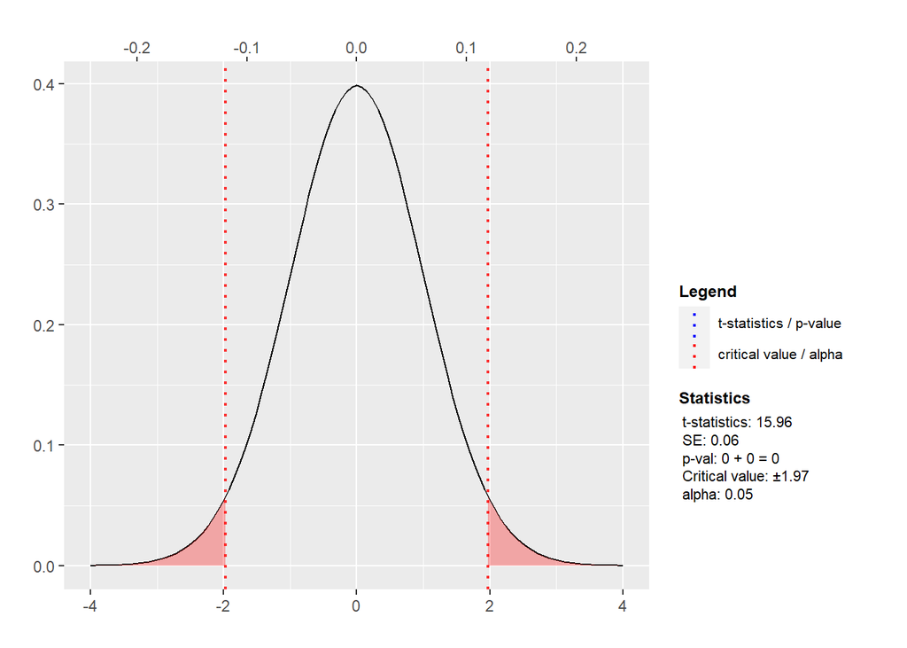

```r
plot_t_distribution(beta_y = 'debt_all_stgp_eval_mean', beta_x = 'coa_grad_res', data_df = df_socialwork)
```

**p-value**

Above, we chose an alpha level of $\alpha= 0.05$; so if our observed p-value is less than .05, then we reject $H_0: \beta_1 = 0$

- from above, our t-statistic of 15.9624 is associated with a p-value of 0
- Decision:
  - we reject $H_0: \beta_1 = 0$
  - we accept $H_a: \beta_1 \ne 0$

And because two-sided alternative hypotheses are at least as conservative as one-sided alternative hypotheses, we can also conclude that $\beta_1 \gt 0$

- that is, we can conclude there is a positive relationship between cost of attendance ($X$) and institution-level student debt ($Y$)

Our estimate $\hat{\beta}_1$ = 0.97 can be interpreted as follows:

- we estimate that a one-dollar increase in annual cost of attendance is associated with a 0.97 dollar increase in the institution-level student debt of students who graduate with an MA in social work

### 7.4.2 Understanding $SE(\hat{\beta_1})$

Anytime we talk about hypothesis testing, we are using estimates from one random sample to make statements about population parameters

- But our estimates differ from population parameters due to random sampling

Standard error (SE) tells us how far away (on average) an estimate is likely to be from population parameter

- The lower our SE, the closer we are to the population parameter!

When is SE($\hat{\beta_1}$) likely to be low?

- When standard error of the regression (SER) is also low (i.e., our predictions are good!)
- When sample size is big [estimates become more precise as sample size increases]
- When the variance of X is high

Below, the number of black and blue dots is the same. Using which sample would you get a more accurate regression line?

- Answer: the black dots (which have greater variance), because it would be more obvious how to draw a line of the linear relationship between $X$ and $Y$

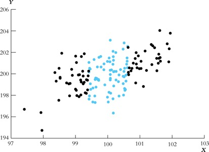

### 7.4.3 Student Exercise about hypothesis testing with ${\beta_1}$

RQ1: What is the relationship between cost of attendance (X) and earnings (Y) (2 year after graduation)?

1. Write out the null and alternative hypotheses for $\beta_1$
2. Run regression in R
   - X= `coa_grad_res`
   - Y= `earn_mdn_hi_2yr`
3. Based on regression output in Q2 and t-statistic formula, show why t=2.087 for $\hat{\beta_1}$
4. Draw sampling distribution of $\hat{\beta_1}$ assuming $H_0$ is true. Label the following:
   - Population regression coefficient associated with $H_0$
   - $\hat{\beta_1}$ and observed t-value
   - Shade in regions for Pr(t<-2.087) and Pr(t>2.087)
   - P-values for regions Pr(t<-2.087) and Pr(t>2.087)

**Student Exercise #3 [SOLUTIONS]**

1. Write out the null and alternative hypotheses for $\beta_1$
   - $H_0: \beta_1 = 0$
   - $H_a: \beta_1 \ne 0$
2. `mod2 <- lm(formula = earn_mdn_hi_2yr ~ coa_grad_res, data = df_socialwork)` `summary(mod2)`

```r
mod2 <- lm(formula = earn_mdn_hi_2yr ~ coa_grad_res, data = df_socialwork)

summary(mod2)$coefficients
```

```
#>                    Estimate    Std. Error   t value                                                                                              Pr(>|t|)
#> (Intercept)  42957.23207812 1241.04363768 34.613797 0.000000000000000000000000000000000000000000000000000000000000000000000000000000000000000000002210637
#> coa_grad_res     0.08524904    0.04083898  2.087443 0.037944420710803221374884941496929968707263469696044921875000000000000000000000000000000000000000000
```

3. t = $\frac {\hat{\beta_1}- \beta_1,0} {SE(\hat{\beta_1})}$ =$\frac {0.08524904 - 0} {0.04083898}$ = 2.087443

[figure not shown]

# 8 Interpretation of $\hat{\beta}$